# Life Sciences Digest

**Week of November 2, 2026**Market data through: October 30, 2026Narrative created: November 2, 2026

Weekly review of pharmaceutical, biotech, biologics, and medical-device company performance, changes, earnings activity, and strategy narrative.

## In the News

### Executive Summary

- Retatrutide’s 20%–21% weight loss versus 9.4% with Ozempic resolves cross-trial uncertainty about its efficacy, although its glycemic advantage was smaller and adverse-event discontinuations were higher. ([Eli Lilly, *Retatrutide delivered greater A1C reduction and more than double the weight loss of Ozempic*, October 28, 2026](https://investor.lilly.com/news-releases/news-release-details/lillys-retatrutide-delivered-greater-a1c-reduction-and-more))
- Petosemtamab plus pembrolizumab reduced mortality risk by 50% in first-line PD-L1-positive head-and-neck cancer, creating a potential chemotherapy-free standard if the detailed safety and absolute survival data hold. (Genmab, *Petosemtamab combination improves overall survival and objective response in LiGeR-HN1*, October 28, 2026)
- Artiva’s discontinuation of AlloNK refutes the premise that deep B-cell depletion and early responses alone justify conditioning-intensive cell therapy in chronic autoimmune disease.
- FDA proposed a single-license pathway for bounded variants of individualized genome-editing products while separately finalizing lifecycle potency standards, shifting the competitive advantage toward platforms with validated manufacturing and assays.
- Voceryq’s accelerated approval validates plasmid DNA immunotherapy commercially, but the evidence consists of 26 efficacy-evaluable patients and requires confirmation through at least three years of follow-up.

### 1. Retatrutide’s advantage over semaglutide is primarily weight loss, not glycemic control

**What changed**

In the 1,298-patient, open-label TRANSCEND-T2D-2 trial, retatrutide lowered A1C by 2.2 percentage points at both doses versus 1.8 points with Ozempic 2 mg after 80 weeks. Weight declined 19.5% and 20.9% with retatrutide 9 mg and 12 mg, respectively, versus 9.4% with Ozempic. Adverse events caused discontinuation in 4.8% and 7.9% of retatrutide recipients versus 2.7% with Ozempic. The reported efficacy estimand assumes participants remained on treatment without prolonged rescue medication. ([Eli Lilly, *Retatrutide delivered greater A1C reduction and more than double the weight loss of Ozempic*, October 28, 2026](https://investor.lilly.com/news-releases/news-release-details/lillys-retatrutide-delivered-greater-a1c-reduction-and-more))

**What it tells us**

The new information is comparative: retatrutide’s approximately 20% weight loss in diabetes is no longer solely a cross-trial observation. The 10- to 11-point weight advantage is clinically substantial; the 0.4-point A1C difference is less differentiated. Higher discontinuation at 12 mg suggests that 9 mg may offer the more commercially usable profile. Ozempic is also a weaker strategic comparator than Lilly’s own tirzepatide, so retatrutide has not yet established superiority over the leading dual agonist.

**What to watch next**

The retatrutide-versus-tirzepatide TRIUMPH-5 trial, treatment-regimen estimand results, cardiovascular outcomes and whether glucagon agonism adds tolerability or lean-mass disadvantages.

### 2. Petosemtamab creates a chemotherapy-free threat to first-line head-and-neck cancer standards

**What changed**

At the first interim analysis of Phase 3 LiGeR-HN1, the EGFRxLGR5 bispecific petosemtamab plus pembrolizumab reduced mortality risk by 50% versus pembrolizumab alone in first-line PD-L1-positive recurrent or metastatic head-and-neck squamous-cell carcinoma (hazard ratio 0.50; 95% confidence interval 0.37–0.67). The combination also met the objective-response endpoint, with 3.17 times the odds of response, and Genmab reported benefit regardless of HPV status. Median survival, absolute response rates and detailed adverse events were not disclosed. (Genmab, *Petosemtamab combination improves overall survival and objective response in LiGeR-HN1*, October 28, 2026)

**What it tells us**

The mortality effect establishes Phase 3 validation for simultaneous EGFR and LGR5 targeting and places petosemtamab ahead of programs supported primarily by response data. Commercially, the immediate opportunity is displacement of pembrolizumab monotherapy. The trial does not resolve competition with pembrolizumab plus chemotherapy, which remains relevant for symptomatic or high-volume disease requiring rapid tumor reduction. A chemotherapy-free regimen could still win broad use if its absolute response rate approaches combination chemotherapy without equivalent toxicity.

**What to watch next**

Median overall survival, response duration, PD-L1 subgroup performance, EGFR-related toxicity and regulatory strategy.

### 3. AlloNK’s failure makes conditioning risk and durability central to autoimmune cell therapy

**What changed**

Artiva discontinued AlloNK, canceled its planned Phase 3 rheumatoid-arthritis trial and began cutting approximately 94% of its workforce after longer-term responses failed to meet the company’s durability threshold. One participant died from leukoencephalopathy assessed as likely caused by fludarabine conditioning; a second died suddenly approximately two months after treatment, with the cause undetermined and assessed as unrelated. FDA had requested a pause in Phase 2a enrollment and dosing. Artiva did not disclose quantitative durability data. ([Artiva Biotherapeutics, *Artiva discontinues development of AlloNK*, October 27, 2026](https://investors.artivabio.com/News-and-Events/news/news-details/2026/Artiva-Biotherapeutics-Announces-Strategic-Update-and-Discontinues-Development-of-AlloNK/default.aspx))

**What it tells us**

This refutes the proposition that an off-the-shelf NK-cell product can translate deep B-cell depletion into a commercially viable autoimmune treatment without demonstrating sustained drug-free control. It does not establish that AlloNK itself caused fatal toxicity; it establishes that lymphodepletion is inseparable from the regimen’s benefit-risk assessment. That distinction matters more in rheumatoid arthritis than in refractory cancer because effective chronic therapies already exist and acceptable mortality risk is correspondingly low.

The result favors platforms pursuing less intensive conditioning, controllable in-vivo cell engineering or antibody-based depletion. It also raises the evidentiary bar: early biomarker depletion must be accompanied by durable clinical remission before pivotal investment.

**What to watch next**

Publication of the fludarabine case, complete response-duration data and conditioning changes across remaining autoimmune cell-therapy programs.

### 4. FDA is reducing genome-editing duplication while raising the manufacturing bar

**What changed**

FDA’s October 28 draft guidance proposes that individualized genome-editing variants targeting pathogenic mutations in the same gene and producing the same editing outcome may share one BLA. New variants within a predefined “individualized feature space” could generally be added through supplements supported by in-vitro activity and safety data rather than additional clinical data. The proposal is limited to qualifying monogenic diseases and does not define the clinical evidence required for initial approval. ([FDA, *Individualized Human Genome Editing Products: Considerations for BLA Submission and Postapproval Management*, October 2026](https://www.fda.gov/media/195887/download))

On November 2, FDA separately finalized guidance requiring a lifecycle potency-assurance strategy addressing raw-material variability, manufacturing controls and biologic-activity testing. ([FDA, *FDA provides clarity to support cell and gene therapy development and quality*, November 2, 2026](https://www.fda.gov/news-events/press-announcements/fda-provides-clarity-support-cell-and-gene-therapy-development-and-quality))

**What it tells us**

FDA is separating reusable platform knowledge from patient-specific product variation. That could make mutation-level portfolios economically feasible by spreading clinical and regulatory costs across multiple variants. The benefit will accrue disproportionately to developers that can define a bounded design space and validate assays across variants.

The final potency guidance prevents this flexibility from becoming regulatory permissiveness. Clinical duplication may decline, but CMC, comparability and assay investment will rise. Manufacturing platforms therefore become as strategically important as editing efficiency.

**What to watch next**

Industry comments, FDA’s promised guidance on clinical evidence and the first BLA that tests whether the framework materially shortens development.

### 5. Voceryq validates plasmid DNA immunotherapy on a narrow evidence base

**What changed**

FDA granted accelerated approval to Inovio’s Voceryq on October 30 to reduce surgical papilloma excisions in adults with recurrent respiratory papillomatosis, making it the first U.S.-approved plasmid DNA-based immunotherapy. Treatment requires surgical debulking followed by four intramuscular doses, three weeks apart, delivered through the CELLECTRA electroporation device. Seven of 26 efficacy-evaluable patients, or 27% (95% confidence interval 12%–48%), required no surgery during the following 12 months in the open-label, single-arm study. ([FDA, *Voceryq prescribing information*, October 2026](https://www.fda.gov/media/196198/download))

**What it tells us**

Avoiding repeated airway surgery is clinically important even if only a minority achieves complete response. The approval also converts plasmid DNA delivery from a long-running platform hypothesis into a regulated product. Its broader scientific read-through remains limited because efficacy was demonstrated in a virally driven, immunologically accessible disease using a small uncontrolled dataset.

Commercial execution requires trained providers, electroporation equipment, initial surgery and payer acceptance of surgery avoidance as value. FDA’s confirmatory requirement calls for at least 50 adult and pediatric patients and three years of post-treatment surgical follow-up. ([FDA, *Voceryq accelerated approval letter*, October 30, 2026](https://www.fda.gov/media/196199/download?attachment=))

**What to watch next**

Launch-site readiness, coverage, response durability and pediatric expansion.

### What to Watch For

- November 27, 2026: Comments close on FDA’s individualized genome-editing draft guidance. ([Federal Register, *Individualized Human Genome Editing Products draft guidance notice*, October 28, 2026](https://www.federalregister.gov/documents/2026/10/28/2026-21954/individualized-human-genome-editing-products-considerations-for-bla-submission-and-postapproval))
- December 10, 2026: FDA hosts its webinar on the final cell-and-gene-therapy potency guidance. ([FDA, *FDA provides clarity to support cell and gene therapy development and quality*, November 2, 2026](https://www.fda.gov/news-events/press-announcements/fda-provides-clarity-support-cell-and-gene-therapy-development-and-quality))
- December 30, 2026: Inovio’s draft Voceryq confirmatory-study protocol is due to FDA. ([FDA, *Voceryq accelerated approval letter*, October 30, 2026](https://www.fda.gov/media/196199/download?attachment=))

### Bottom Line

This week strengthened two high-value therapeutic propositions: triple-agonist metabolic therapy can materially outperform semaglutide on weight, and EGFRxLGR5 targeting can extend survival in head-and-neck cancer. The counterweight was Artiva’s failure, which shows that autoimmune cell therapy must deliver durable remission with a conditioning regimen acceptable for chronic disease; detailed petosemtamab results are the next evidence most likely to change the near-term view.

## Recent Earnings Highlights

Companies covered in this section:

- Eli Lilly (LLY)
- AbbVie (ABBV)
- Merck (MRK)
- Novartis (NVS)
- AstraZeneca (AZN)
- Gilead (GILD)
- Bristol Myers Squibb (BMY)
- Stryker (SYK)
- Sanofi (SNY)
- GSK (GSK)
- Regeneron (REGN)
- Boston Scientific (BSX)
- Dexcom (DXCM)
- ResMed (RMD)
- GE Healthcare (GEHC)
- Biogen (BIIB)
- Alnylam (ALNY)
- Incyte (INCY)
- BridgeBio Pharma (BBIO)
- Exelixis (EXEL)
- Krystal Biotech (KRYS)
- Novocure (NVCR)

Eli Lilly is a drug firm with a focus on neuroscience, cardiometabolic, cancer, and immunology. Lilly's key products include Verzenio and Jaypirca for cancer; Mounjaro, Zepbound, Foundayo, Jardiance, Trulicity, Humalog, and Humulin for cardiometabolic; and Taltz and Olumiant for immunology.

**Reported:** October 29, 2026 · [Google Finance earnings page](https://www.google.com/finance/quote/LLY:NYSE?tab=earnings&hl=en)

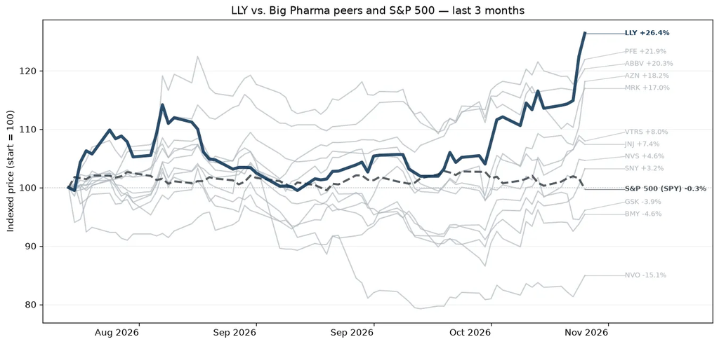

#### Reported Results

Q3 2026: EPS $7.48 vs. $6.35 est. (+17.88%); revenue $24.40B vs. $22.62B est. (+7.88%)

#### Earnings Call Summary

Eli Lilly reported strong Q3 2026 results, with revenue growing 39% year-over-year to $24.397B, driven by Mounjaro, Zepbound, and strong momentum across therapeutic areas. Non-GAAP EPS reached $7.48, despite $4.57 per share in acquired IPR&D charges. Gross margin expanded 80 basis points to 84.4% due to favorable product mix and improved production costs.

#### Key Moments from the Call

- **11m 53s — Full-Year 2026 Guidance Boosted Significantly:** Lilly increased full-year revenue expectations to $91B-$92B and EPS to $35-$36, pleasing investors by exceeding internal models due to faster-than-expected uptake of the Medicare GLP-1 Bridge Program and strong international demand.
- **13m 56s — Next-Generation Incretin Pipelines Show Superior Efficacy:** Phase III retatrutide data achieved over 20% weight loss, doubling semaglutide's results, while EloraTZP delivered 23.3% weight loss in Phase II. These breakthroughs reassure investors that Lilly will maintain its long-term market dominance.
- **35m 23s — Medicare GLP-1 Bridge Driving High Adherence:** The Medicare Bridge program has seen 80% naive patient entry and improved therapy adherence due to low out-of-pocket friction, validating the long-term volume runway and health economics of the obesity franchise.
- **37m 56s — Foundayo Oral Launch Expands Global Reach:** Foundayo captured 45% of sequential oral obesity growth in the U.S. and is tracking above expectations in recent international rollouts, proving the oral option successfully expands the total addressable market.

AbbVie is a pharmaceutical firm with a strong exposure to immunology (with Humira, Skyrizi, and Rinvoq) and oncology (with Imbruvica and Venclexta). The company was spun off from Abbott in early 2013. The 2020 acquisition of Allergan added several new products and drugs in aesthetics, including Botox. The 2024 acquisitions of Cerevel (neuroscience) and ImmunoGen (oncology) help supplement AbbVie's portfolio.

**Reported:** October 30, 2026 · [Google Finance earnings page](https://www.google.com/finance/quote/ABBV:NYSE?tab=earnings&hl=en)

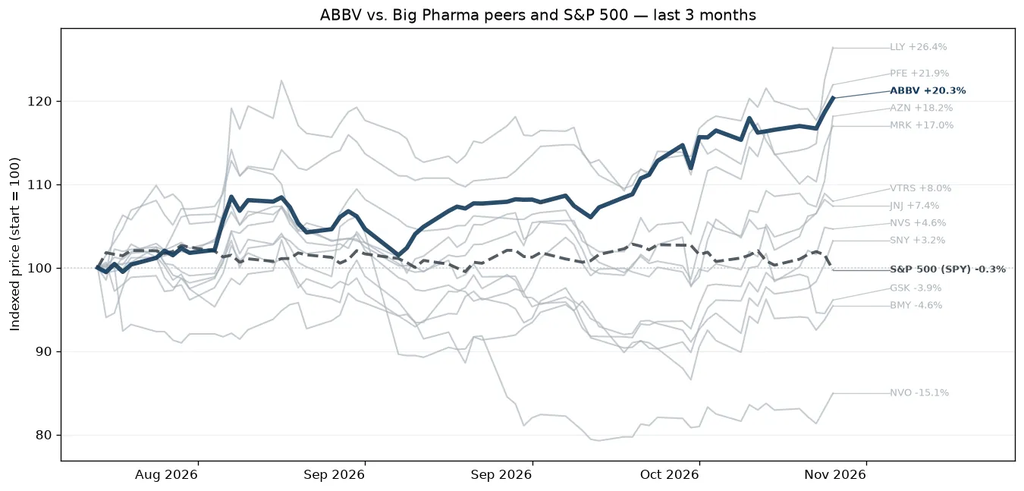

#### Reported Results

Q3 2026: EPS $3.82 vs. $3.78 est. (+1.09%); revenue $17.40B vs. $17.34B est. (+0.35%)

#### Earnings Call Summary

AbbVie reported strong Q3 2026 adjusted EPS of $3.82, beating guidance by $0.07 despite an $0.11 impact from acquired IPR&D. Total net revenue reached $17.4 billion, exceeding expectations by $200 million and delivering robust operational sales growth of over 10.5%, driven by double-digit growth across nine key products.

#### Key Moments from the Call

- **1m 38s — Full-Year Guidance Raised Again:** AbbVie raised its 2026 full-year revenue outlook by $200 million to $67.8 billion and adjusted EPS guidance midpoint to $13.95–$13.99. This marks a cumulative $800 million upward revenue revision since the start of the year, pleasing investors by signaling continuous strong commercial performance and operational momentum across key franchises.
- **6m 45s — SKYRIZI Subcutaneous Crohn's Launch:** The FDA approval of SKYRIZI subcutaneous induction for Crohn's disease offers superior clinical efficacy over its IV formulation. Management expects this differentiated on-body injector delivery to accelerate new patient market share over the coming quarters, strengthening their competitive edge against rival advanced IBD therapies.
- **64m 48s — Favorable BOTOX Litigation Ruling:** A federal district court ruled in AbbVie's favor that BOTOX is ineligible for Medicare price selection under the IRA because it contains human serum albumin. This shields a vital multi-billion dollar franchise from near-term government pricing pressures, removing a significant overhang for investors.
- **73m 45s — New Dermatology Indications for RINVOQ:** RINVOQ is expanding into vitiligo and alopecia areata, with approvals anticipated in the U.S. in the coming months. Management raised its peak sales projection for these combined derm indications to over $2 billion, targeting a highly underserved, naive patient market via an expanded commercial sales force.

Merck makes pharmaceutical products to treat several conditions in a number of therapeutic areas, including cardiometabolic disease, cancer, and infections. Within cancer, the firm's immuno-oncology platform, led by Keytruda, is a major contributor to overall sales. The company also has a substantial vaccine business aimed at preventing pediatric diseases, as well as Gardasil for human papillomavirus. Additionally, Merck sells animal health-related drugs. From a geographical perspective, 47% of the company's sales are generated from US human health (pharmaceuticals and vaccines).

**Reported:** October 29, 2026 · [Google Finance earnings page](https://www.google.com/finance/quote/MRK:NYSE?tab=earnings&hl=en)

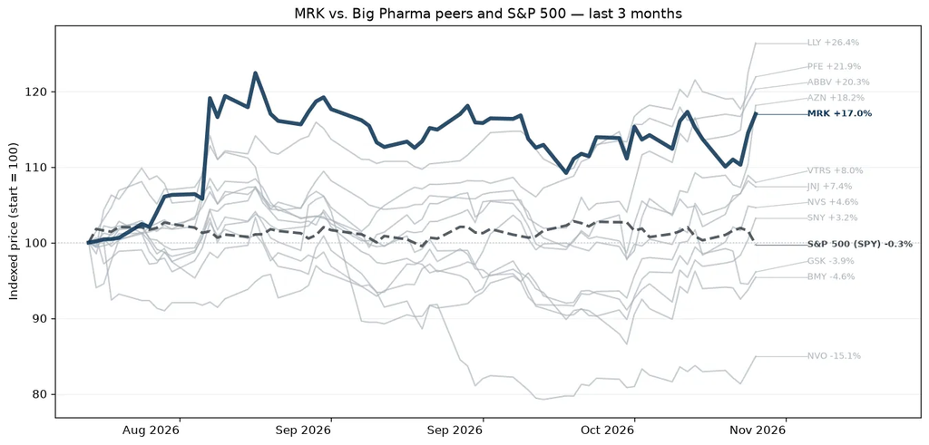

#### Reported Results

Q3 2026: EPS $2.49 vs. $2.09 est. (+19.30%); revenue $18.09B vs. $17.33B est. (+4.35%)

#### Earnings Call Summary

Merck delivered Q3 2026 revenue of $18.1 billion, representing a 5% increase year-over-year (4% ex-exchange). Growth was driven by key product launches, oncology, and animal health, despite a $550 million U.S. customer purchase timing headwind that was partially offset by a channel inventory build expected to unwind.

#### Key Moments from the Call

- **10m 50s — 2026 Guidance Raise and 2027 Headwinds:** Merck raised its full-year 2026 EPS and revenue outlook, but management explicitly flagged that 2027 will see moderating revenue growth and over $2 billion in headwinds from generic entrants impacting BRIDION and JANUVIA alongside rising R&D investment costs.
- **37m 54s — KEYTRUDA QLEX European Legal Injunctions:** Management addressed ongoing subcu KEYTRUDA (QLEX) patent litigation in Europe, confirming that a Dutch court injunction halts supply in six smaller European countries for now, but reassures that major markets like the U.S., U.K., and Japan remain unaffected.
- **48m 19s — LIPFENDRA Launch Metrics and Inertia:** Merck shared early performance data for LIPFENDRA, tracking over 11,000 prescriptions from 6,500 doctors. Management emphasized that broad market expansion beyond the PCSK9 class is occurring, though payer coverage will build gradually through 2027 and 2028.
- **54m 36s — Confidence in Long-Term $70B Target:** CEO Rob Davis expressed higher confidence in the mid-2030s $70 billion revenue target, noting plans to raise expectations due to recent asset additions like Terns, strong data for PD-1 VEGF and sac-TMT, and superior clinical performance from intismeran.

Novartis develops and manufactures innovative drugs. Key areas of drug development are oncology, immunology, neuroscience, respiratory, and cardiovascular, renal, and metabolic. It also has an established medicines business, which includes off-patent franchises. The company sells its products globally, with the United States constituting close to one-third of total revenue.

**Reported:** October 27, 2026 · [Google Finance earnings page](https://www.google.com/finance/quote/NVS:NYSE?tab=earnings&hl=en)

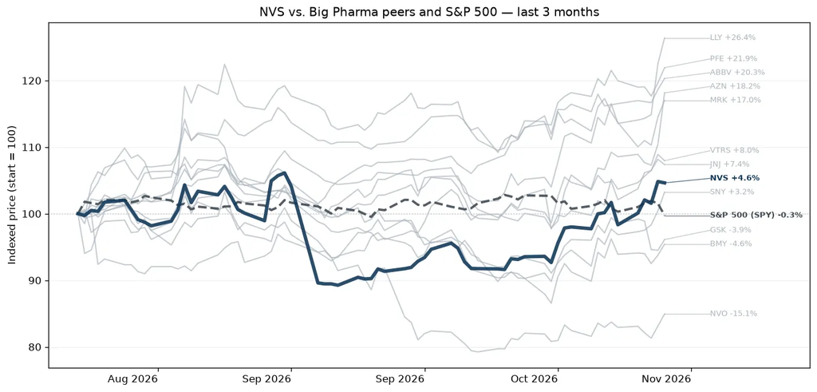

#### Reported Results

Q3 2026: EPS $2.46 vs. $2.24 est. (+9.74%); revenue $15.03B vs. $14.56B est. (+3.25%)

#### Key Moments from the Call

- **10m 51s — Rhapsido Peak Sales Target Lifted:** Management boosted Rhapsido's peak sales projection to over $4B following strong launch trajectories and a new FDA approval for symptomatic dermographism. This structural target change will please investors looking for reliable, high-margin blockbusters to carry top-line growth deep into the next decade.
- **12m 40s — Del-desiran Failure and Pipeline Impairment:** The phase III HARBOR trial for del-desiran missed its primary endpoint, forcing a $1.9B partial asset write-down. This setback will disappoint investors, as it pushes back launch timelines and mandates an extra phase III trial to salvage the regulatory path forward.
- **19m 19s — Upgraded Core Operating Income Guidance:** Novartis upgraded its 2026 full-year core operating income guidance to grow low double digits, reversing previous expectations of a low single-digit decline. This surprises investors positively, proving the company's productivity initiatives and core brand momentum can offset the steep erosion from generic Entresto in the U.S.
- **28m 1s — Durable SG&A Cost Reductions:** Novartis drove Q3 SG&A expenses 7% lower year-over-year while revenue expanded 4%. Analysts heavily probed the durability of this margin enhancement, and management reassured the market that technology- and AI-driven structural efficiencies are securely locking in a clear path toward 40%+ operating margins by 2029.

A merger between Astra of Sweden and Zeneca of the United Kingdom formed AstraZeneca in 1999. The firm sells branded drugs across a number of major therapeutic areas, including oncology (over 40% of total revenue), cardiovascular, renal, and metabolic (over 20%), rare disease (16%), and respiratory and immunology (15%). The majority of sales comes from international markets, with the United States representing close to one-third of its sales.

**Reported:** October 30, 2026 · [Google Finance earnings page](https://www.google.com/finance/quote/AZN:NYSE?tab=earnings&hl=en)

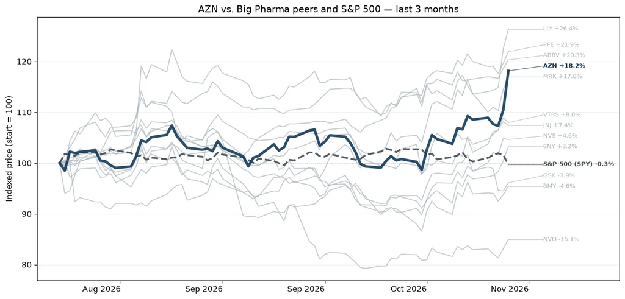

#### Reported Results

Q3 2026: EPS $2.79 vs. $2.59 est. (+7.92%); revenue $16.21B vs. $16.00B est. (+1.34%)

#### Earnings Call Summary

AstraZeneca reported total revenue growth of 7% and core EPS growth of 14% for the first nine months of 2026. Excluding Farxiga and Brilinta, total revenue grew 12%, demonstrating portfolio strength across oncology, rare disease, and R&I, which helped offset expected headwinds from loss of exclusivity in CVRM.

#### Key Moments from the Call

- **13m 55s — Reshaping for Sustainable Growth Program:** AstraZeneca announced a new restructuring program to optimize clinical trial footprints and embed AI technologies. This initiative involves $2 billion in restructuring costs to achieve $1.5 billion in annual savings by 2029, allowing the company to aggressively reinvest in its late-stage pipeline without expanding its base costs.
- **15m 10s — Tagrisso Milestone and Expansion Strategy:** Tagrisso quarterly revenue exceeded $2 billion for the first time, growing 12%. New Phase III data from SAFFRON and SANOVO will help protect the franchise from competitor entry by establishing combination pathways that extend treatment duration and maintain Tagrisso as the core therapeutic backbone.
- **26m 34s — LOE and VBP Headwinds in CVRM:** Biopharmaceuticals revenue dropped 6% in the quarter to $5.6 billion, severely impacted by an 18% decline in the CVRM segment. This downturn reflects the anticipated loss of exclusivity for Farxiga in the U.S. and volume-based procurement impacts in China, partially offset by respiratory and immunology growth.
- **42m 4s — Pipeline Acceleration and 2027 Catalysts:** Management projected an exceptionally rich catalyst year in 2027, expecting over 20 Phase III readouts representing more than $20 billion in non-risk-adjusted peak sales potential. This extensive pipeline progress underpins management's confidence in completely offsetting upcoming patent losses and sustaining long-term growth past 2030.

Gilead Sciences develops and markets therapies to treat and prevent life-threatening infectious diseases, with the core of its portfolio focused on HIV and hepatitis B and C. Gilead's acquisition of Pharmasset brought rights to hepatitis C drug Sovaldi, which is also part of newer combination regimens that remain standards of care. Gilead is also growing its presence in the oncology market via acquisitions, led by CAR-T cell therapy Yescarta/Tecartus (from Kite) and breast and bladder cancer therapy Trodelvy (from Immunomedics).

**Reported:** October 29, 2026 · [Google Finance earnings page](https://www.google.com/finance/quote/GILD:NASDAQ?tab=earnings&hl=en)

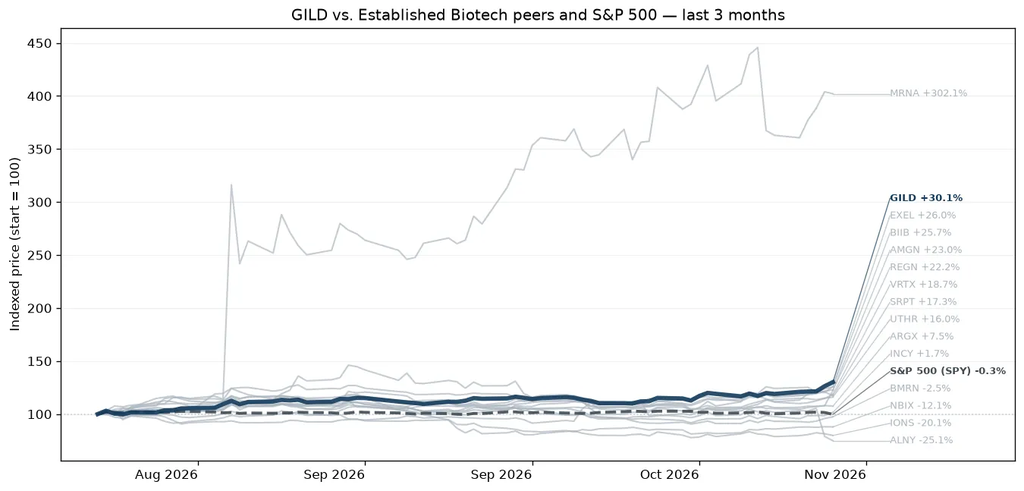

#### Reported Results

Q3 2026: EPS $2.55 vs. $2.19 est. (+16.23%); revenue $8.30B vs. $7.80B est. (+6.36%)

#### Earnings Call Summary

Gilead reported strong Q3 2026 results with base business sales up 16% year-over-year, its strongest growth in over a decade. This was driven by double-digit growth across key treatments: HIV sales grew 18% YoY, Biktarvy hit all-time high U.S. market share, and oncology asset Trodelvy surged 42% YoY to an approximately $2 billion annual run rate.

#### Key Moments from the Call

- **13m 56s — Cell Therapy Declines and Trial Holds:** Investors will face hurdles as cell therapy sales fell 18% year-over-year due to competitive headwinds. Additionally, next-gen cell therapy trials PALISADES-1 and 2 were placed on a partial clinical hold to investigate elevated grade 3 and 4 ICANS safety events.
- **13m 56s — Imminent Launch Catalyst for Anito-Cel:** Management generated positive sentiment ahead of multiple myeloma therapy anito-cel's December 23 PDUFA date. Gilead is aggressively pre-activating 80% of its treatment network to secure a rapid rollout and targets brand leadership within 18 months of approval.
- **33m 17s — Strong Full-Year 2026 Guidance Raise:** Gilead pleased the market by raising full-year base product sales guidance by $900 million at the midpoint, predicting 12% YoY HIV growth. Excluding heavy acquisition-related upfront charges, underlying EPS targets were boosted by $0.25 on both ends.
- **37m 30s — Biktarvy CMS Price Setting Disappointment:** CMS set Biktarvy's Medicare price at $2,600 per 30-day supply, a massive 38% discount from list price. Management expects a net full-year 2028 revenue hit of $1.5 billion across Medicare and spillover channels, sparking concerns despite long-term growth forecasts.

Bristol Myers Squibb discovers, develops, and markets drugs for various therapeutic areas, such as cardiovascular, cancer, and immune disorders. A key focus for Bristol is immuno-oncology, where the firm is a leader in drug development. Bristol derives close to 70% of total sales from the US, showing a higher dependence on the US market than most of its peer group.

**Reported:** October 29, 2026 · [Google Finance earnings page](https://www.google.com/finance/quote/BMY:NYSE?tab=earnings&hl=en)

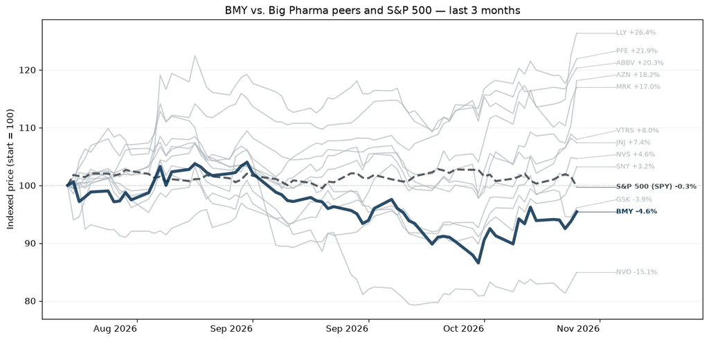

#### Reported Results

Q3 2026: EPS $1.35 vs. $1.22 est. (+10.27%); revenue $13.07B vs. $12.72B est. (+2.72%)

#### Earnings Call Summary

Bristol Myers Squibb reported strong Q3 2026 results, with total revenue increasing 7% year-over-year to $13.1B, driven by 12% growth in its growth portfolio ($7.7B). Performance was bolstered by double-digit gains in key brands like REBLOZYL, BREYANZI, OPDUALAG, and ELIQUIS, though OPDIVO revenue decreased 6% due to conversion to subcutaneous QVANTIG.

#### Key Moments from the Call

- **2m 21s — Full Year Guidance Raised:** Bristol Myers Squibb raised its full-year 2026 financial guidance following strong execution across the growth portfolio and robust ELIQUIS performance, giving the company positive operational momentum heading into 2027.
- **16m 25s — Admilparant High Dose Efficacy Profile:** Investors may query why the 120 mg high dose of admilparant missed statistical significance in the ALOFT-IPF study, though management remains highly confident in the 60 mg dose data and the drug's safety profile.
- **20m 41s — Milvexian Trial Readiness and Timelines:** Management expressed confidence in upcoming phase III readouts for milvexian, with secondary stroke prevention data expected by year-end 2026 and atrial fibrillation data in Q1 2027, balancing initial disclosures with later medical conference presentations.
- **55m 29s — Zola-cel Clinical Program Restart:** Addressing a patient fatality from sepsis pneumonia during a voluntary study pause, management identified a reagent-related root cause, made adjustments, and is working closely with regulators to resume the autoimmune CAR T program quickly.

Stryker designs, manufactures, and markets an array of medical equipment, instruments, consumable supplies, and implantable devices. The product portfolio includes hip and knee replacements, extremities, endoscopy systems, operating room equipment, embolic coils, mechanical thrombectomy systems, hospital beds and gurneys, and orthopedic robotics. Stryker remains one of the three largest competitors in reconstructive orthopedic implants and holds the leadership position in operating room equipment. Roughly one-fourth of Stryker's total revenue currently comes from outside the United States.

**Reported:** October 29, 2026 · [Google Finance earnings page](https://www.google.com/finance/quote/SYK:NYSE?tab=earnings&hl=en)

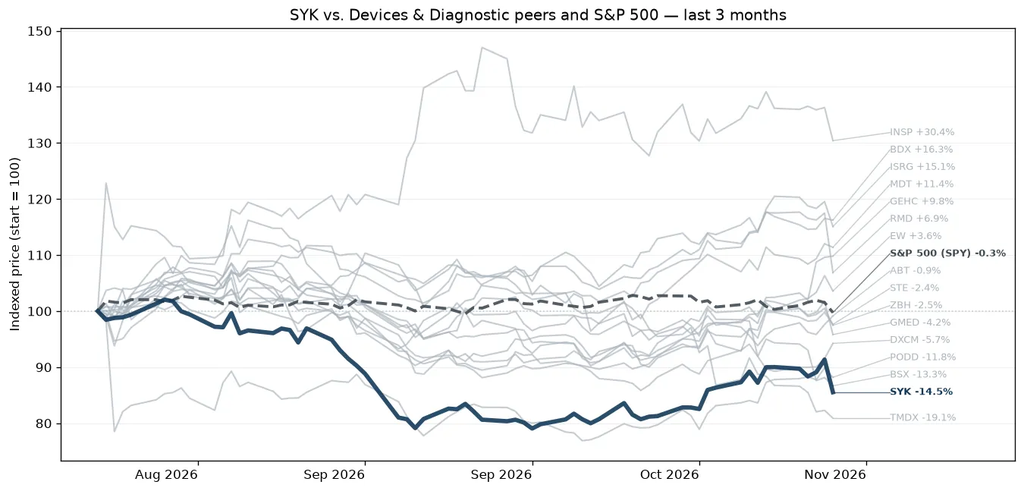

#### Reported Results

Q3 2026: EPS $3.52 vs. $3.55 est. (-0.77%); revenue $6.52B vs. $6.62B est. (-1.47%)

#### Earnings Call Summary

Stryker reported 7.7% organic sales growth for Q3 2026, driven by 9.1% growth in MedSurg and Neurotechnology and 5.9% growth in Orthopaedics. While key divisions like Endoscopy and Ortho Tech delivered double-digit performances, overall results fell short of corporate expectations due to specific business challenges.

#### Key Moments from the Call

- **1m 41s — Orthopedic Market Deceleration:** Management revealed that U.S. joint reconstruction is experiencing a pronounced slowdown, with market growth stepping down to ~2.5%. Affordability headwinds from rising insurance costs and elevated pre-authorization denials are discouraging patients from seeking timely hip and knee treatments, shocking long-term structural assumptions.
- **2m 42s — Commercial Execution Gaps From SAP:** A July SAP implementation in the Orthopaedics segment caused severe order-entry delays and internal distractions, contributing to a failure to win market share at historical rates. The lack of commercial visibility masked the market slowdown, magnifying operational execution risks for key launches like Mako RPS.
- **5m 59s — Strategic Entry Into Soft Tissue Robotics:** The exclusive U.S. partnership and equity stake in CMR Surgical marks a major expansion into soft tissue robotics, an adjacent market dominated by a large incumbent. Investors will look closely at this capital-efficient commercial strategy designed to capture untapped general surgery volumes before a planned full buyout.
- **11m 35s — Full-Year Guidance Cut:** Stryker lowered its full-year organic net sales growth guidance to 6.5%-7.0% and adjusted EPS to $14.80-$14.90. The downward revision directly highlights an unexpected macroeconomic and procedural slowdown in core orthopedic markets, alongside persistent supply disruptions in its peripheral vascular business.

Sanofi develops and markets drugs with a concentration in immunology, vaccines, and rare diseases. Although the company offers a diverse array of drugs, its highest-revenue product, Dupixent, accounts for over 30% of total sales. Profits for this immunology blockbuster drug are shared with Regeneron. About 45% of total revenue comes from the United States, 20% from Europe, and 6% from China.

**Reported:** October 30, 2026 · [Google Finance earnings page](https://www.google.com/finance/quote/SNY:NASDAQ?tab=earnings&hl=en)

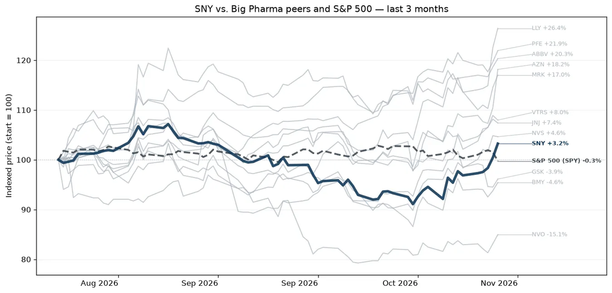

#### Reported Results

Q3 2026: EPS $1.98 vs. $1.51 est. (+31.19%); revenue $15.23B vs. $13.33B est. (+14.25%)

#### Earnings Call Summary

Sanofi reported total sales of EUR 14.4 billion for Q3 2026, marking a 14.3% year-over-year increase driven by strong demand across pharma launches and Dupixent. Business EPS grew 19.6%, delivering profitable growth supported by operating leverage and gross margin expansion of 2.1 percentage points.

#### Key Moments from the Call

- **6m 28s — Regeneron Alliance Expanded for Post-LOE Growth:** Sanofi expanded its partnership with Regeneron to secure four next-generation long-acting antibodies. The strategic shift directly targets sustaining immunology leadership, with clinical entry planned to introduce follow-on treatments prior to Dupixent losing exclusivity next decade.
- **16m 30s — Gross-to-Net Control Drives EPS Beat:** Operational improvements, including deploying AI tools to manage gross-to-net provisions and policing 340B rebate utilization in the U.S., contributed an estimated 2 percentage points of one-off growth, materially expanding Q3 margins and surprising analysts during the Q&A segment.
- **18m 36s — Full-Year 2026 Guidance Upgraded:** Sanofi upgraded its 2026 outlook, now targeting sales growth in the low teens (13%-15%) and business EPS growth in the mid-teens (15%-17%). This reflects robust demand-driven momentum and positive price base adjustments that exceeded prior expectations.
- **28m 31s — Major Pipeline Discontinuations After Review:** Following a rigorous technical assessment under new R&D leadership, Sanofi terminated global development of amlitelimab in atopic dermatitis and itepekimab in COPD. This active portfolio pruning surprises the market but underscores a disciplined data-driven approach to pipeline execution.

In the pharmaceutical industry, GSK ranks as one of the largest firms by total sales. The company wields its might across several therapeutic classes, including respiratory, antiviral, and vaccines, and has been growing its presence in oncology and immunology, as well. GSK uses joint ventures to gain additional scale in certain markets like HIV.

**Reported:** October 28, 2026 · [Google Finance earnings page](https://www.google.com/finance/quote/GSK:NYSE?tab=earnings&hl=en)

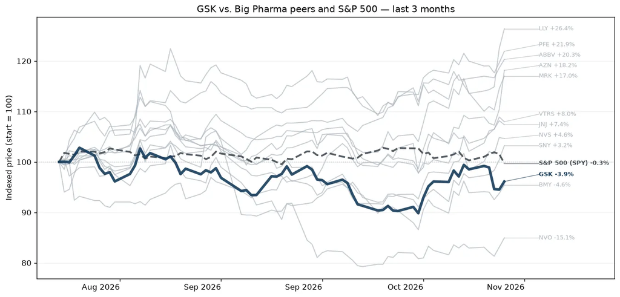

#### Reported Results

Q3 2026: EPS $1.45 vs. $1.33 est. (+9.46%); revenue $8.89B vs. $8.84B est. (+0.54%)

#### Earnings Call Summary

GSK reported a strong Q3 2026 performance with sales increasing 5% to £8.9 billion, driven primarily by momentum in its specialty medicines portfolio. Core operating profit grew by 5% and cash generation reached £7.4 billion year-to-date, prompting management to reconfirm its full-year 2026 guidance.

#### Key Moments from the Call

- **0m 29s — Specialty Growth Reconfirms Guidance:** GSK's Q3 2026 sales rose 5% to £8.9 billion, meeting internal expectations and allowing management to comfortably reconfirm its full-year guidance, driven primarily by strong commercial execution in specialty oncology and respiratory launches.
- **20m 56s — Aggressive R&D Reallocation and Charges:** R&D spend surged 22% in Q3 to fund an unprecedented 18 Phase III study starts. This pipeline velocity triggered a £0.3 billion restructuring charge in the quarter, with full-year organizational simplification costs now expected to reach up to £1.1 billion.
- **29m 41s — HIV Long-Acting Pipeline Clarity:** Analysts heavily pressed management on ongoing pharmacokinetic analyses for the four-monthly HIV PrEP formulation. Executives emphasized that while the data is still being evaluated for regulators, the underlying formulation remains sound and has no negative read-through to their clinical treatment candidates.
- **56m 21s — Inflation Reduction Act Commercial Rebasing:** Management detailed upcoming commercial headwinds for 2027, highlighting that Trelegy's addition to the CMS list under the Inflation Reduction Act will introduce a one-off U.S. price rebase via a 73% discount to its previous list price.

Regeneron Pharmaceuticals discovers, develops, and commercializes products that fight eye disease, cardiovascular disease, cancer, and inflammation. The company has several marketed products, including low-dose Eylea and Eylea HD, approved for wet age-related macular degeneration and other eye diseases; Dupixent in immunology; Praluent for LDL cholesterol lowering; Libtayo in oncology; Kevzara in rheumatoid arthritis; and Lynozyfic for multiple myeloma. Regeneron has multiple partnerships and collaboration agreements, with Sanofi (Dupixent, others) and Bayer (Eylea) as its largest partners.

**Reported:** October 30, 2026 · [Google Finance earnings page](https://www.google.com/finance/quote/REGN:NASDAQ?tab=earnings&hl=en)

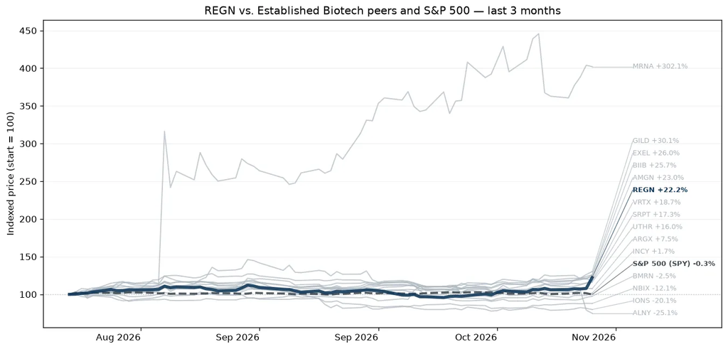

#### Reported Results

Q3 2026: EPS $20.07 vs. $16.19 est. (+23.93%); revenue $5.12B vs. $4.56B est. (+12.14%)

#### At a Glance

- **Regeneron Beats Earnings and Revenue:** Regeneron reported a total revenue of $5.12 billion, comfortably beating the estimated $4.56 billion, while non-GAAP adjusted EPS came in at $20.07, surpassing the analyst consensus estimate of $16.19.
- **Key Blockbusters Drive Dynamic Growth:** Global net sales of Dupixent climbed 35% year-over-year to $6.5 billion, and U.S. sales of EYLEA HD surged 62% to $699 million, effectively helping to offset a 41% decline in legacy EYLEA sales caused by biosimilar competition.
- **Expanded Alliance and Heightened Guidance:** The company expanded its alliance with Sanofi, securing a $1.0 billion upfront payment for fourth-quarter revenue, while management forecast mid-teens percentage R&D expense growth in 2027 to fuel large late-stage programs.
- **Strategic Pivot to In-Licensing:** Management signaled a fundamental shift in business development strategy, transitioning from historical net out-licensing to actively evaluating external innovation from early-stage platforms up to commercial assets.
- **Positive Market Response Materializes:** Following the substantial financial surprise, Regeneron's stock price surged over 13% during regular trading to finish near its 52-week high.

#### Key Moments from the Call

- **24m 11s — EYLEA HD Dosing Enhancements:** EYLEA HD sequential demand growth is guided at low-to-mid teens for H2 2026, offsetting upcoming 2mg biosimilar headwinds on legacy EYLEA. Momentum will be further assisted by the targeted end-of-year FDA approval of the EYLEA HD pre-filled syringe enhancement.
- **30m 56s — Full Sanofi Balance Repayment:** Regeneron completely paid off its $3.1B Sanofi development balance, removing a major headwind that reduced historical revenue by $930M in 2025. This ensures a significant step-up in high-margin collaboration revenue starting in Q3 2026, pleasing investors.
- **37m 39s — Dupixent Alliance Expansion:** Management revealed active and productive early discussions with Sanofi's new CEO to expand their decades-long partnership to include Regeneron's next-generation follow-on programs, including a long-acting IL-13 antibody, maximizing commercial efficiency.
- **54m 17s — Differentiated Obesity Profile:** Instead of just chasing marginal percentage gains in weight loss, Regeneron is differentiating its upcoming Phase III obesity programs by focusing on significant muscle mass preservation and co-treating cardiovascular risks alongside dual GLP-1 receptor agonist olatorepatide.

Boston Scientific focuses on less invasive medical devices that are inserted into the human body through small openings or cuts. It manufactures products for use in angioplasty, blood clot filtration, kidney stone management, cardiac rhythm management, catheter-directed ultrasound imaging, upper gastrointestinal tract diagnostics, interventional oncology, neuromodulation for chronic pain, and treatment of incontinence. The firm markets its devices to healthcare professionals and institutions globally. Foreign sales account for roughly 36% of the firm's total sales.

**Reported:** October 28, 2026 · [Google Finance earnings page](https://www.google.com/finance/quote/BSX:NYSE?tab=earnings&hl=en)

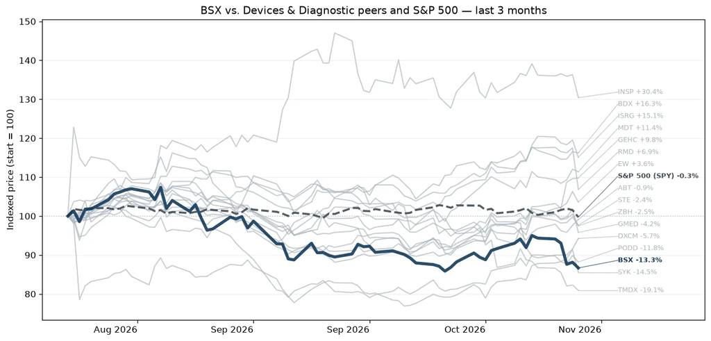

#### Reported Results

Q3 2026: EPS $0.73 vs. $0.72 est. (+0.94%); revenue $5.14B vs. $5.05B est. (+1.66%)

#### Earnings Call Summary

Boston Scientific reported Q3 2026 total company organic sales growth of 1.5% year-over-year, missing its original guidance of 3%-5%. Adjusted EPS was $0.73, down 3% year-over-year and below the guided range of $0.80-$0.82. Performance was heavily impacted by a cybersecurity incident that reduced organic sales growth by approximately 300 basis points.

#### Key Moments from the Call

- **28m 15s — Severe Cyber Incident Disrupts Operations:** A two-week operational outage from a cybersecurity incident severely impacted financial metrics, creating a $150 million top-line headwind (300 basis points) and a $0.07 negative impact to adjusted EPS in Q3. Elevated customer ordering at the end of Q3 will continue to burn off, creating a further 200 to 300 basis point headwind in Q4.
- **29m 27s — Cyclical Growth Pressures and 2027 Outlook Decline:** A sharp competitive turnaround in the high-growth WATCHMAN and EP franchises is weighing heavily on total company performance. Combined with accelerating pricing pressures in China, management delivered a disappointing outlook, projecting flat-to-negative operational and EPS growth for the full year 2027 as they work toward a cyclical trough.
- **56m 32s — Key Product Launches Facing Multi-Quarter Delays:** Investors will face extended timelines for critical pipeline products that drive future margin expansion. The FARAWAVE Ultra launch has slipped to early 2028 due to extended design verification hurdles, while the FARAFLEX wide area focal catheter timeline has been pushed to 2029 following regulatory negotiations with the FDA and operational site setup challenges.
- **58m 41s — Penumbra Transaction Timeline Extends into 2027:** The strategic acquisition of Penumbra has been delayed, with the closing timeline pushed into early first quarter 2027 due to ongoing regulatory reviews. Furthermore, rising interest rates since the initial deal announcement will drive higher incremental financing costs, which is expected to increase near-term EPS dilution beyond the previously estimated $0.06-$0.08 range.

DexCom designs and commercializes continuous glucose monitoring systems for diabetic patients. CGM systems serve as an alternative to the traditional blood glucose meter process, and the company is evolving its CGM systems to provide integration with insulin pumps from Insulet and Tandem for automatic insulin delivery. DexCom's CGMs are available through medical equipment distributors as well as retail pharmacies.

**Reported:** October 29, 2026 · [Google Finance earnings page](https://www.google.com/finance/quote/DXCM:NASDAQ?tab=earnings&hl=en)

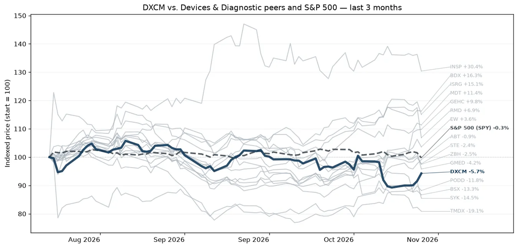

#### Reported Results

Q3 2026: EPS $0.73 vs. $0.67 est. (+8.31%); revenue $1.34B vs. $1.33B est. (+1.34%)

#### Earnings Call Summary

Dexcom reported Q3 2026 worldwide revenue of $1.34 billion, representing 11% year-over-year organic and reported growth, driven by a stable double-digit expanding active base and record global new patient starts. Total revenue outpaced analyst expectations of $1.33 billion, while reported EPS of $0.73 beat estimates by roughly $0.06.

#### At a Glance

- **Dexcom Beats Q3 Revenue Expectations:** Dexcom reported Q3 2026 revenue of $1.3445 billion, beating the estimated $1.3267 billion, while reported adjusted EPS came in at $0.73, surpassing expectations of $0.674.
- **Gross Margin Hits Record Levels:** Dexcom's non-GAAP gross margin expanded by 380 basis points year-over-year to 65.1%, reaching its highest level since 2022 due to manufacturing efficiencies and improved freight costs.
- **Full Year Revenue Guidance Lifted:** Management raised its full-year 2026 revenue guidance to a range of $5.20 billion to $5.25 billion, passing through the Q3 outperformance while factoring in $5 million in foreign exchange headwinds.
- **Strong Adoption of G7 System:** The company's G7 15-day system remains on track to convert nearly 50% of the U.S. customer base by the end of 2026, with an international launch scheduled for Canada in November 2026.
- **Market Expansion in Diabetes Segments:** Dexcom achieved strong market-share gains and near-record new patient starts, with the largest volume of growth emerging from type 2 non-insulin diabetes patients.
- **New Share Repurchase Program Authorized:** Demonstrating its robust financial position and generation of over $900 million in free cash flow, Dexcom authorized a new $1 billion share repurchase program for 2027.

#### Key Moments from the Call

- **13m 56s — A New Capital Allocation Move:** Having completed its 2026 objective to buy back $1 billion of equity, Dexcom authorized a new $1 billion share repurchase program. The fresh authorization aligns with a corporate strategy to deploy a minimum of 50% of the free cash flow generated throughout fiscal year 2027 directly toward stock buybacks.
- **14m 46s — European Expansion Via Direct Operations:** Dexcom announced it has signed a definitive agreement to acquire its largest remaining European distributor business. Expected to close in 2027, the transaction allows the company to transition to direct operations in high-potential European markets, securing downstream commercial alignment to support aggressive access and growth strategies.
- **18m 29s — Strong Margins Refute Competitor Pricing Concerns:** Management pushed back against sector-wide concerns regarding global continuous glucose monitor pricing degradation, emphasizing that their tiered product strategy has kept pricing stable. This stability is directly reflected in Q3 gross margins hitting 65.1%, their highest level since the final quarter of 2022.
- **26m 34s — Mitigating A Minor PBM Contract Loss:** Executives minimized a recent CVS PBM contract loss, stating the PBM accounts for under 4% of U.S. revenue. Moving to a non-preferred status unlocks contractual price increases that financially offset volume risks. Additionally, a new 'Dexcom Direct' portal will launch in early 2027 to smoothly transition disrupted patients to medical benefits.

ResMed is one of the largest respiratory care device companies globally, primarily developing and supplying flow generators, masks, and accessories for the treatment of sleep apnea. Increasing diagnosis of sleep apnea combined with aging populations and increasing prevalence of obesity is resulting in a structurally growing market. The company earns roughly two-thirds of its revenue in the Americas and the balance across other regions dominated by Europe, Japan, and Australia. Recent developments and acquisitions have focused on digital health as ResMed is aiming to differentiate itself through the provision of clinical data for use by the patient, medical care advisor, and payer in the out-of-hospital setting.

**Reported:** October 29, 2026 · [Google Finance earnings page](https://www.google.com/finance/quote/RMD:NYSE?tab=earnings&hl=en)

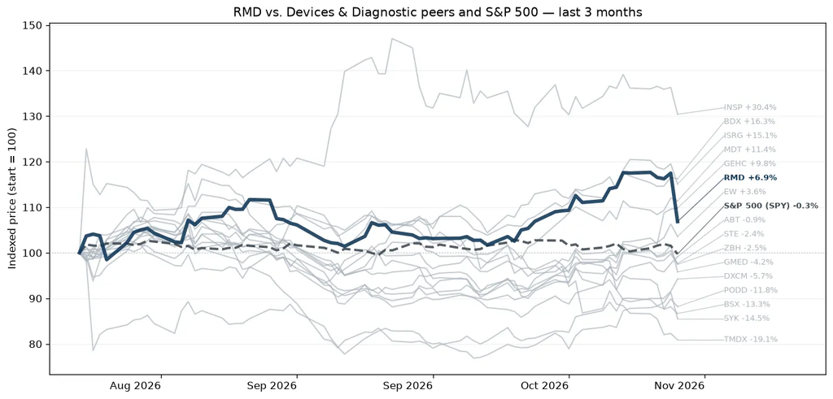

#### Reported Results

Q1 2027: EPS $2.91 vs. $2.67 est. (+8.86%); revenue $1.41B vs. $1.39B est. (+1.55%)

#### Earnings Call Summary

ResMed reported strong Q1 2027 results, delivering 7% revenue growth on a core constant currency basis and a 50 basis point year-over-year gross margin expansion. Non-GAAP earnings per share increased by 14% to $2.91. The company returned over $1 billion to shareholders through quarterly dividends and share repurchases, funded partly by the MatrixCare divestiture.

#### Key Moments from the Call

- **34m 37s — Gross Margin Outperformance:** Non-GAAP gross margin improved 50 basis points year-over-year to 62.5%, beating expectations. The outperformance was primarily driven by manufacturing productivity and the favorable shifting of supply chain expansion costs, particularly for the Indiana facility, into the second quarter.
- **37m 9s — International Sleep Device Surge:** Rest of world sleep device revenue surged 13% during the quarter. This significant outperformance was driven by a temporary PAP fleet renewal program in France moving clients from AirSense 10 to AirSense 11 devices, which management notes will turn into a headwind in the back half of the year.
- **45m 41s — Guidance Maintained Despite Beat:** Despite beating Q1 estimates on top and bottom lines, management prudently maintained its full-year guidance. Rationale includes potential back-half headwinds from the conclusion of France's fleet renewal, building inflationary pressures on electronic components, and the time required for new marketing campaigns to impact the middle funnel.
- **55m 59s — Fabric Mask Innovation:** ResMed launched its third fabric mask, the AirTouch F40, targeting the oro-nasal category. Real-world compliance data indicates a 6% increase in therapy adherence for fabric masks over silicone equivalents, strengthening ResMed's IP and competitive moat against returning market participants.

GE HealthCare Technologies is a leading medical technology firm with leading market share in imaging and ultrasound equipment. The company reports four major segments: imaging (45% of revenue), advanced visualization solutions (26%), patient care solutions (15%), and pharmaceutical diagnostics (14%). The company's sales are geographically diverse, with the United States, EMEA, China, and the rest of the world accounting for 46%, 26%, 11%, and 17%, respectively. We estimate approximately half of its revenue is recurring, which consists of servicing (about one-third of revenue), pharmaceutical diagnostics (about 10%-15%), and digital solutions (just over 5%).

**Reported:** October 28, 2026 · [Google Finance earnings page](https://www.google.com/finance/quote/GEHC:NASDAQ?tab=earnings&hl=en)

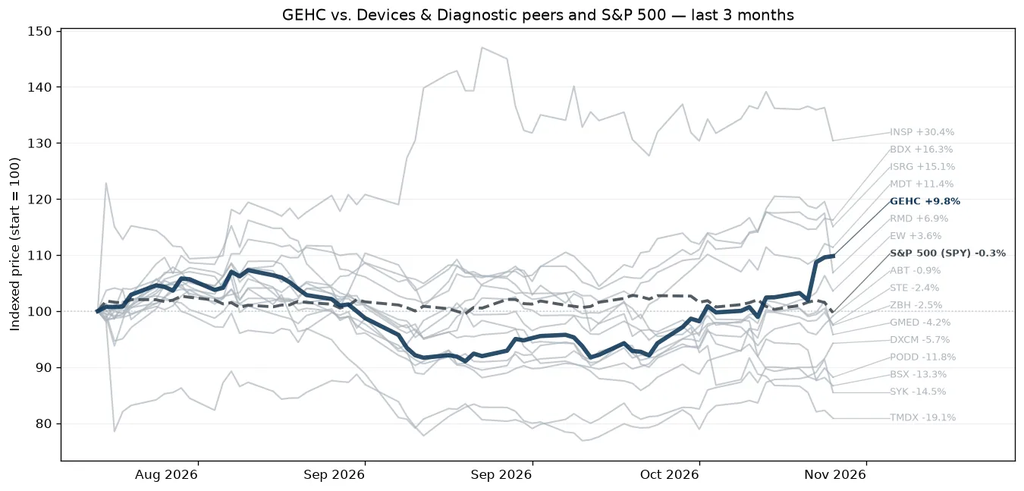

#### Reported Results

Q3 2026: EPS $1.34 vs. $1.20 est. (+11.28%); revenue $5.51B vs. $5.35B est. (+3.01%)

#### Earnings Call Summary

GE HealthCare delivered strong Q3 2026 performance with reported revenue of $5.5 billion, up 6.2% organically, driven by broad-based demand across all segments. Product and service revenues grew 6.7% and 8.1% respectively. Organic orders rose 4%, and book-to-bill reached 1.03x, exiting the quarter with a record $23.7 billion backlog, up 12% year-over-year.

#### Key Moments from the Call

- **6m 29s — Strong Financial Results and Guidance Increase:** GE HealthCare delivered Q3 revenue of $5.5 billion and adjusted EPS of $1.34, exceeding market expectations. This performance was supported by a robust 12% backlog growth. This clear operational momentum gave management the confidence to raise its full year 2026 adjusted EPS guidance to a strong $4.95-$5.05 range, which will reassure investors.
- **10m 20s — Patient Care Solutions Turnaround:** Patient Care Solutions achieved a notable turnaround with 8.8% organic growth and 480 basis points of margin expansion. By utilizing the 'Heartbeat' operating system to resolve previous supply chain constraints and implement daily management, the segment showed significant operational healing that should comfort investors who were previously concerned about its negative trend.
- **15m 14s — Strategic M&A with SOFIE Biosciences:** The planned acquisition of SOFIE Biosciences will expand GE HealthCare's final-mile U.S. PET radiopharmaceutical manufacturing network. Expected to add 1% to total revenue with accretive margins, the deal strengthens the company's pipeline with FAPI-74 and protects its radiopharmaceutical supply chain against the transport vulnerabilities of short half-life tracers.
- **17m 58s — Macro Environment Resilience:** Management reported a strong hospital capital equipment environment, noting that imaging remains a top priority for hospital CFOs. Furthermore, the company's China business showed signs of recovery with 7% growth in the quarter, and supply lines for critical memory chips have been proactively secured through multi-year agreements to combat cross-industry AI demand.

### Biogen (BIIB) +25.0% Last 3m

Biogen is an established biopharmaceutical company focused on treatments for neurodegenerative and rare diseases. Its declining multiple sclerosis franchise is its largest revenue generator and contributed 40% of total revenue in 2025. Biogen also generates significant revenue from its CD20 collaboration agreements with Roche (19% of total in 2025), which includes oncology drugs Rituxan and Gazyva and multiple sclerosis drug Ocrevus. Biogen's newer franchises include Spinraza (spinal muscular atrophy, with partner Ionis), Leqembi (Alzheimer's disease, collabroation revenue from its partner Eisai), Skyclarys (Friedreich's ataxia, Reata), Zurzuvae (postpartum depression, Sage), and Qalsody (amyotrophic lateral sclerosis, Ionis).

**Reported:** October 28, 2026 · [Google Finance earnings page](https://www.google.com/finance/quote/BIIB:NASDAQ?tab=earnings&hl=en)

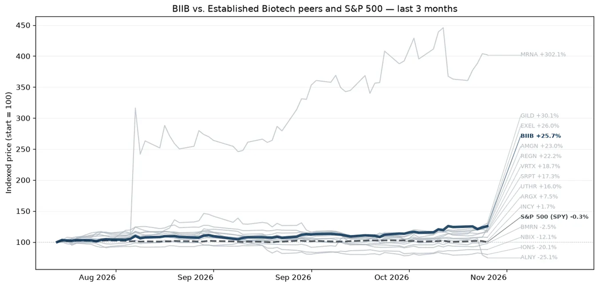

#### Reported Results

Q3 2026: EPS $2.62 vs. $1.99 est. (+31.53%); revenue $2.80B vs. $2.63B est. (+6.56%)

#### Earnings Call Summary

Biogen reported strong Q3 2026 financial performance, with total revenue increasing 11% year-over-year to $2.8 billion, heavily supported by the Apellis acquisition. The commercial growth portfolio reached $1.26 billion, delivering a robust 50% year-over-year growth and accounting for nearly two-thirds of core pharmaceutical revenue.

#### Key Moments from the Call

- **8m 40s — Early Research Overhaul Nets Record INDs:** After going three years without a single Investigational New Drug application, a radical overhaul of early development yielded 5 INDs in 2026. This structural shift toward balancing portfolio risk provides a long-term commercial foundation beyond the current late-stage pipeline.
- **22m 44s — Apellis Deal Dilution Reduced, Guidance Raised:** Faster synergy capture from the Apellis acquisition minimized operating dilution in the first year. Consequently, Biogen raised the lower end of its full-year 2026 non-GAAP diluted EPS range to between $12.20 and $13.00, reassuring investors of immediate transaction value.
- **28m 10s — Felzartamab Protocol Strategy Accelerates Market Readiness:** Biogen has deployed medical teams to 100 transplant centers ahead of data readouts for felzartamab in AMR. By navigating institutional protocols early, management mitigates post-approval commercial delays and establishes immediate pricing leverage based on a heavy front-loaded dosing schedule.
- **45m 42s — IQLIK Subcutaneous Adoption Signals Market Expansion:** The subcutaneous IQLIK formulation is outpacing the original LEQEMBI IV launch by 3.5 times. Crucially, it is attracting physicians who have never prescribed Alzheimer's treatments before, proving its convenience factor is actively expanding the addressable market.

Alnylam Pharmaceuticals is a leader in the study of RNA interference (RNAi) therapeutics. RNAi is a naturally occurring biological pathway within cells for sequence-specific silencing and regulation of gene expression. Alnylam's commercial RNAi therapeutic products include Onpattro and Amvuttra (for hATTR amyloidosis), Givlaari (for acute hepatic porphyria), and Oxlumo (for primary hyperoxaluria type 1), all developed and commercialized by Alnylam. Plus, Leqvio (for hypercholesterolemia) and Qfitlia (for hemophilia A or B), which are being commercialized by Alnylam's partners, Novartis and Sanofi, respectively. It also has several clinical programs across various therapeutic areas, including cardio-metabolic diseases, neuroscience, and hematology.

**Reported:** October 29, 2026 · [Google Finance earnings page](https://www.google.com/finance/quote/ALNY:NASDAQ?tab=earnings&hl=en)

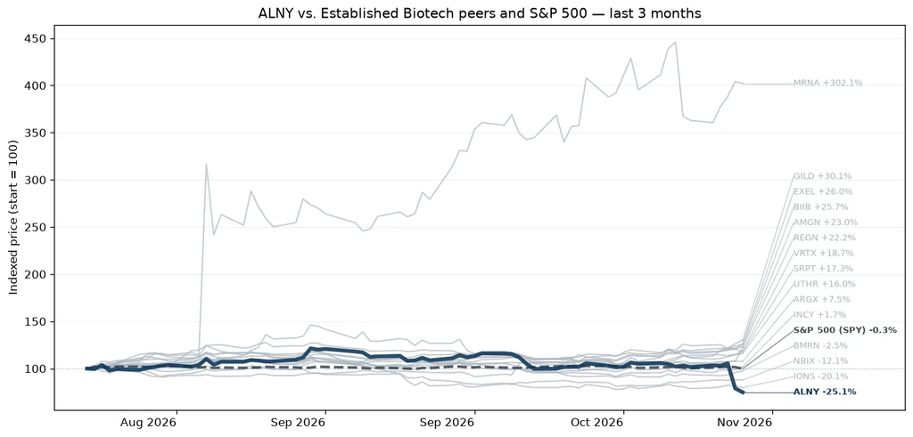

#### Reported Results

Q3 2026: EPS $16.26 vs. $2.25 est. (+623.00%); revenue $1.46B vs. $1.43B est. (+2.03%)

#### Earnings Call Summary

Alnylam Pharmaceuticals reported strong Q3 2026 product revenues growing 52% year-over-year to $1.29B, led by the TTR franchise which grew 59% YoY to $1.15B. Growth was primarily driven by AMVUTTRA uptake in ATTR cardiomyopathy, though management expressed they are not yet satisfied with underlying demand growth as sales expansions take time to convert to patient starts.

#### Key Moments from the Call

- **12m 51s — Mitigation Strategy for Impending 340B Cuts:** To address severe impending CMS reimbursement cuts to 340B hospitals effective 2027, management presented detailed contingency plans. Alnylam will offer direct volume contracting discounts to keep care economical for hospitals or pivot patients to their established network of 2,000 third-party infusion clinics and home-care options, defending net pricing and patient retention.
- **17m 54s — TRITON-CM Upsizing Post-Competitor Failure:** Alnylam expanded its nucresiran TRITON-CM study by 500 patients, explicitly learning from the failure of Ionis/AstraZeneca's eplontersen in CARDIO-TTRansform. The expansion protects the event-driven trial from declining baseline cardiovascular events driven by earlier patient diagnosis and modern background therapies, bolstering investor confidence in an optimized, highly powerful study layout.
- **21m 31s — Pivotal Trial Strategy for Huntington's Disease:** Following encouraging Phase I results for brezosiran that showed 60%-64% mean maximum reductions of CSF mutant huntingtin without adverse safety signals, Alnylam announced it will skip straight to a large placebo-controlled pivotal study in 2027. This move positions brezosiran as a vital pipeline asset to diversify the company beyond its primary TTR focus.
- **28m 54s — Lower-End Guidance and Halted 2027 Outlook:** Management projected TTR sales at the low end of their guidance range, citing slower field force conversion and a restrictive insurance policy by UnitedHealth. Due to impending 340B policy changes and expected hospital ordering volatility, the company uncharacteristically delayed its 2027 financial guidance, opting to provide it in mid-February instead of at the January JPMorgan conference.

### Incyte (INCY) +0.7% Last 3m

Incyte focuses on the discovery and development of small-molecule drugs. The firm's leading drug, Jakafi, treats two types of rare blood cancer and graft versus host disease and is partnered with Novartis. Incyte's other marketed drugs include rheumatoid arthritis treatment Olumiant (licensed to Lilly), and oncology drugs Iclusig (chronic myeloid leukemia), Pemazyre (cholangiocarcinoma), Tabrecta (lung cancer), and Monjuvi (diffuse large B-cell lymphoma). The firm's first dermatology product, Opzelura, was approved in 2021 for atopic dermatitis and 2022 for vitiligo. Incyte's pipeline includes an array of oncology and dermatology programs.

**Reported:** October 29, 2026 · [Google Finance earnings page](https://www.google.com/finance/quote/INCY:NASDAQ?tab=earnings&hl=en)

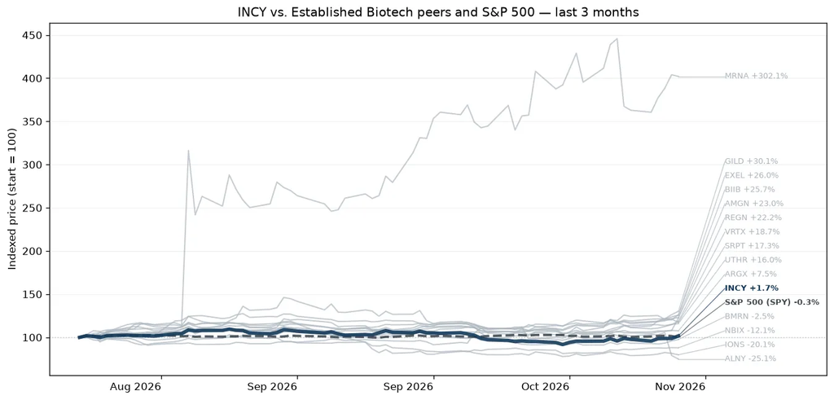

#### Reported Results

Q3 2026: EPS -$3.60 vs. -$3.87 est. (+6.93%); revenue $1.56B vs. $1.46B est. (+6.48%)

#### Earnings Call Summary

Incyte reported total Q3 2026 revenue of $1.56 billion and total net sales of $1.32 billion, both up 14% year-over-year. Core business net sales excluding Jakafi rose 30% to $490 million, driven by growth in brands like OPZELURA (+36% to $255M). Growth across brands and geographies strengthens the outlook towards achieving $3B-$4B by 2030.

#### Key Moments from the Call

- **18m 22s — Deprioritizing Platinum-Resistant Ovarian Cancer Asset:** Management decided to stop additional site activation and future enrollment for the phase III MAESTRA-2 study of CDK2 inhibitor 667 in platinum-resistant ovarian cancer. Shifting dynamics and competing ADCs limited commercial prospects, pushing the company to refocus 667 exclusively on first-line maintenance, potentially disappointing investors counting on the late-stage indication.
- **21m 21s — Vega Acquisition Drives Higher Near-Term Expenses:** Incyte closed its acquisition of Vega Therapeutics, triggering a $1.23 billion upfront IPR&D expense that drove GAAP expenses up 146% to $2.27 billion. Although this impacted near-term profitability, it adds latarcibart, a phase III non-factor replacement asset for von Willebrand disease, extending the long-term pipeline horizon.
- **23m 30s — Raised Full-Year 2026 Net Sales Guidance:** Incyte raised its total full-year net sales guidance to $5.210B-$5.300B, up from previous expectations, driven by strong growth across key brands. OPZELURA full-year guidance was elevated to $1.1B-$1.12B, while hematology and oncology was increased to $890M-$910M, providing a strong positive signal to investors regarding core demand.
- **36m 4s — Comprehensive Pipeline Expansion Post-2029 Focus:** With Jakafi's upcoming 2029 transition, analysts heavily focused on late-stage pipeline assets. Incyte highlighted six assets currently in phase III or under regulatory review. Upcoming first-line MF data for 989 at ASH and imminent regulatory decisions for povorcitinib in HS serve as critical near-term clinical anchors to replace legacy revenue.

### BridgeBio Pharma (BBIO) -6.4% Last 3m

BridgeBio Pharma is a biotechnology company focused on discovering, developing, testing, and delivering transformative treatments for patients with genetic diseases. The company has four programs in its late-stage pipeline focusing on Mendelian disorders, oncology, and gene therapy. One of its key programs, Attruby (acoramidis), is an orally administered small molecule designed to stabilize tetrameric transthyretin for the treatment of transthyretin amyloid cardiomyopathy.

**Reported:** October 29, 2026 · [Google Finance earnings page](https://www.google.com/finance/quote/BBIO:NASDAQ?tab=earnings&hl=en)

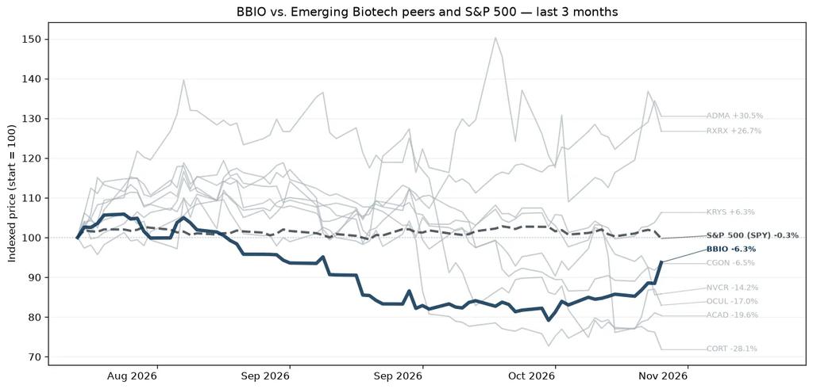

#### Reported Results

Q3 2026: EPS -$0.42 vs. -$0.56 est. (+24.59%); revenue $353.17M vs. $295.75M est. (+19.41%)

#### Earnings Call Summary

BridgeBio reported Q3 2026 total revenues of $353.2 million, up from $120.7 million in Q3 2025. This outperformance was driven by Attruby U.S. net product revenue rising 134% year-over-year to $253.2 million and a $75 million one-time sales milestone from Bayer for Beyonttra in Europe.

#### Key Moments from the Call

- **7m 38s — Strong Real-World Evidence Differentiation:** Management highlighted new real-world data from the Komodo database and Epic Cosmos showing acoramidis achieved significant reductions in cardiovascular hospitalizations and early clinical worsening compared to tafamidis. This provides a robust competitive moat to drive market share in the critical first-line setting.
- **14m 9s — Imminent BBP-418 Regulatory Decision:** Investors will focus on the upcoming November 27, 2026 PDUFA date for BBP-418 in LGMD2I. Management expressed confidence in achieving a traditional full approval based on ongoing positive interactions with the FDA, and has already identified more than 500 unique patients in the United States.
- **15m 56s — Three Priority Review Launches Ahead:** With $1.5 billion in cash, BridgeBio is fully funded for three sequential rare disease launches over the next seven months. Infigratinib's PDUFA is set for February 4, 2027, and encaleret's PDUFA is May 8, 2027, positioning the company to maximize its multi-billion dollar pipeline potential.
- **30m 5s — Attruby Outperformance and Financial Trajectory:** BridgeBio generated Q3 2026 revenue of $353.2 million, significantly beating the estimated $295.75 million, while reported EPS of -$0.42 beat the estimated -$0.557. Growth was propelled by a 134% year-over-year increase in U.S. Attruby sales and a $75 million milestone payment from Bayer, demonstrating operational leverage.

Exelixis Inc is a biopharmaceutical firm that discovers, develops, and commercializes treatments for cancer. Its molecule, cabozantinib, is indicated for the treatment of patients with metastatic medullary thyroid cancer under the name Cometriq and for the treatment of kidney and liver cancer under the name Cabometyx. Exelixis and its partner Roche have also brought Cotellic to market for the treatment of melanoma.

**Reported:** October 29, 2026 · [Google Finance earnings page](https://www.google.com/finance/quote/EXEL:NASDAQ?tab=earnings&hl=en)

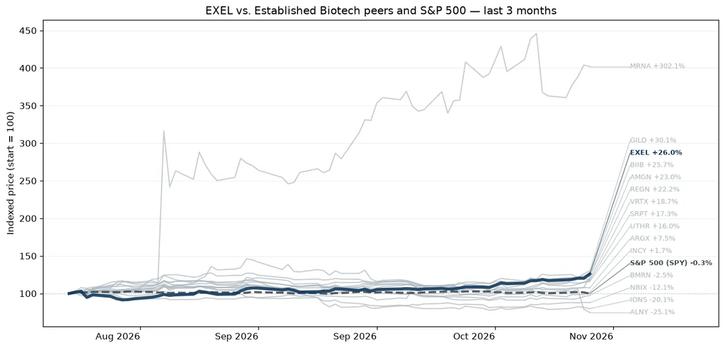

#### Reported Results

Q3 2026: EPS $0.94 vs. $0.92 est. (+2.73%); revenue $658.70M vs. $646.77M est. (+1.84%)

#### Earnings Call Summary

Exelixis reported total Q3 2026 revenue of $659M, beating estimates, with U.S. cabozantinib product revenue up 11% year-over-year to $605M. Non-GAAP diluted EPS was $0.94, outperforming expectations. Global CABO franchise revenue grew 11% to $818M, while gross-to-net deductions decreased due to lower 340B discounts, leading to an updated full-year forecast of 30%.

#### Key Moments from the Call

- **10m 48s — Zanzalintinib PDUFA Date and Pipeline Progress:** Investors will be pleased with the clear regulatory timeline for zanza in colorectal cancer, with an established PDUFA date of March 3, 2027. This provides visibility for its transition to commercialization, which targets an addressable $1.5 billion total market opportunity and leverages substantial provider overlap with the existing cabozantinib franchise footprint.
- **11m 40s — STELLAR-304 Top-Line Results Timeline Specified:** Management narrowed expectations for top-line data from the Phase III STELLAR-304 trial in non-clear cell RCC to Q1 2027. While representing a slight shift, nearing the clinical cutoff builds anticipation for a second potential NDA submission, supporting strategic efforts to maximize market penetration in advanced kidney cancer indications.
- **20m 23s — Strong Commercial Momentum for CABOMETYX Franchise:** CABOMETYX demonstrated durable competitive health, expanding its total prescription volume by 13% year-over-year and securing a 49% market basket share. Furthermore, surpassing a 50% new patient share in second-line plus neuroendocrine tumors solidifies stable baseline revenue generation to self-fund the company's escalating oncology research priorities.
- **52m 21s — Rapid Enrollment Confirms Bladder Cancer Opportunity:** An exceptionally fast phase I enrollment rate for zanza in post-EV/pembro bladder cancer validates substantial unaddressed demand in solid tumors. This clinical momentum supports management's strategic vision of establishing zanza as a universal combination backbone alongside standard-of-care immunotherapies or advanced cytotoxic payloads.

Krystal Biotech Inc is an integrated, commercial-stage biotechnology company focused on the discovery, development, manufacturing, and commercialization of genetic medicines to treat diseases with high unmet medical needs. The company uses its patented HSV-1-based gene therapy platform to create vectors that deliver therapeutic transgenes to target cells. It possesses exclusive rights to develop, manufacture, and commercialize VYJUVEK internationally. The company operates as one operating segment focused on pharmaceutical products and manufactures, markets, and sells VYJUVEK in the United States and markets and sells VYJUVEK in the European Union, and Japan.

**Reported:** November 2, 2026 · [Google Finance earnings page](https://www.google.com/finance/quote/KRYS:NASDAQ?tab=earnings&hl=en)

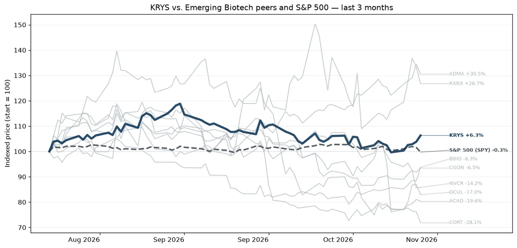

#### Reported Results

Q3 2026: EPS $2.05 vs. $1.92 est. (+6.88%); revenue $127.34M vs. $126.54M est. (+0.63%)

#### Earnings Call Summary

Krystal Biotech delivered strong Q3 2026 results with global VYJUVEK revenue reaching $127.3 million, a 30% increase year-over-year from $97.8 million. Diluted EPS was reported at $2.05, and the company concluded September with $1.2 billion in cash and investments. The board also authorized a share repurchase program of up to $400 million over two years.

#### At a Glance

- **Krystal Biotech Tops Earnings Estimates:** Krystal Biotech reported a reported revenue of $127,341,000, beating the estimated revenue of $126,540,390, while its reported EPS reached $2.05, outperforming the consensus estimate.
- **VYJUVEK Sales Drive Growth Higher:** VYJUVEK net product revenue surged 30% year-over-year to $127.3 million, supported by sustained U.S. adoption and initial international launches.
- **Spending Revised Down and Repurchases Authorized:** Management lowered its full-year non-GAAP R&D and SG&A expense guidance to $155M–$165M and authorized a new $400 million share repurchase program over the next two years.
- **Pipeline Delays Push Expectations Out:** Clinical readouts for key pipeline programs, including KB801 and KB803, have been pushed into 2027 due to stringent trial eligibility and enrollment challenges.
- **Stock Declines Despite Financial Beat:** Krystal Biotech stock fell over 3% to 5% following the announcement as investors shifted focus toward future growth velocity and pipeline timelines over the current quarter's beat.
- **International Launches Impact Gross Margin:** Gross margin for the quarter edged down slightly to 94% from 96% in the prior year, reflecting international rollouts that haven't yet benefited from U.S. manufacturing improvements.

#### Key Moments from the Call

- **3m 41s — Strategic Share Repurchase Program:** Management pleased investors by authorizing a $400 million share repurchase program over the next two years, signaling strong confidence in the company's long-term intrinsic value and capitalizing on a robust $1.2 billion cash reserve.
- **10m 59s — Impressive Gorlin Syndrome Efficacy:** KB113 pilot data will delight investors by showing a robust anti-tumor response in Gorlin syndrome. Substantial regression in non-injected lesions provides key proof of a systemic abscopal effect, enabling positive development pathway discussions with the FDA.
- **14m 45s — Clinical Readout Delays Across Pipeline:** Investors will face delayed clinical timelines as top-line results for the KB803 registrational study, KB801 in NK, and interim data for KB407 in cystic fibrosis have all been pushed out to 2027 due to slow enrollment, strict screening criteria, and protocol updates.
- **21m 54s — FY2026 Expense Guidance Revised Downward:** Krystal Biotech lowered its full-year non-GAAP R&D and SG&A guidance to $155 million-$165 million from the prior $175 million-$195 million range, demonstrating strong cost controls that support bottom-line profitability.

NovoCure Ltd is an oncology company with a proprietary platform technology in the United States. Its business involves the development, manufacture, and commercialization of Tumor Treating Fields (TTFields) devices, including Optune Gio and Optune Lua, for the treatment of solid tumor cancers. Its pipeline consists of Trident, Lunar-2, Panova-3, Metis, and other products and technologies for the treatment of Glioblastoma, Non-small cell lung cancer, and Pancreatic cancer. Geographically, the company derives the majority of its revenue from the United States and the rest from Germany, Japan, and other markets.

**Reported:** October 29, 2026 · [Google Finance earnings page](https://www.google.com/finance/quote/NVCR:NASDAQ?tab=earnings&hl=en)

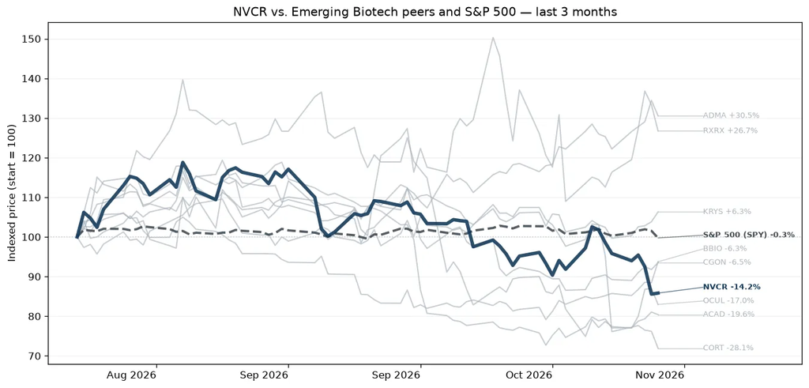

#### Reported Results

Q3 2026: EPS -$0.09 vs. -$0.23 est. (+61.68%); revenue $193.40M vs. $182.23M est. (+6.13%)

#### Earnings Call Summary

The Optune Gio glioblastoma business grew 11% year-over-year to a record 4,729 active patients on therapy. NovoCure is targeting increased adoption across active markets and expects its phase III KEYNOTE-D58 trial, evaluating pembrolizumab with Optune Gio, to complete enrollment by year-end 2026.

#### Key Moments from the Call

- **6m 16s — Optune Pax U.S. Launch Headwinds:** U.S. launch momentum for Optune Pax slowed significantly because clinical practices are overwhelmed handling insurance appeals and managing side effects for the newly introduced drug daraxonrasib. This temporary practice disruption has restricted NovoCure's field teams from effectively accessing clinics to secure prescriptions.
- **7m 9s — New Pancreatic Cancer Clinical Collaborations:** NovoCure announced the PANOVA-5 and PANOVA-6 trials for the first half of 2027, exploring combinations of Optune Pax with Verastem's KRAS inhibitor and daraxonrasib. These trials address market concerns by generating vital data on using Tumor Treating Fields alongside emerging standards of care.
- **10m 35s — Raised Full-Year 2026 Guidance Range:** NovoCure raised its 2026 net revenue guidance to between $736 million and $743 million, representing 12% to 13% growth. Full-year adjusted EBITDA guidance was also increased to a range of $24 million to $34 million, reflecting strong financial performance and rigid operating expense controls.
- **13m 21s — Positive Adjusted EBITDA Milestone Achieved:** NovoCure achieved its first positive adjusted EBITDA quarter in over four years at $16 million, checking off the first step of its three-part profitability strategy. Management aims to leverage existing commercial infrastructure to transition to cash flow breakeven next, followed by GAAP net income profitability.

## Upcoming Earnings

### Devices & Diagnostic

| Company | Ticker | Date | Market cap | 3m Return | 12m Return |
| --- | --- | --- | --- | --- | --- |
| Edwards LifeSciences | [EW](https://www.google.com/finance/quote/EW:NYSE?hl=en) | November 4, 2026 | $51.6B | +6.9% | +11.6% |
| Becton Dickinson | [BDX](https://www.google.com/finance/quote/BDX:NYSE?hl=en) | November 5, 2026 | $48.2B | +19.5% | +10.7% |
| STERIS | [STE](https://www.google.com/finance/quote/STE:NYSE?hl=en) | November 5, 2026 | $22.7B | -0.6% | -3.6% |
| Zimmer Biomet | [ZBH](https://www.google.com/finance/quote/ZBH:NYSE?hl=en) | November 4, 2026 | $18.5B | +0.6% | -6.0% |
| Insulet | [PODD](https://www.google.com/finance/quote/PODD:NASDAQ?hl=en) | November 4, 2026 | $11.6B | -9.5% | -52.2% |
| Globus Medical | [GMED](https://www.google.com/finance/quote/GMED:NYSE?hl=en) | November 5, 2026 | $11.1B | -0.9% | +29.2% |
| Transmedics | [TMDX](https://www.google.com/finance/quote/TMDX:NASDAQ?hl=en) | November 5, 2026 | $2.8B | -13.7% | -49.8% |
| Inspire Medical Systems | [INSP](https://www.google.com/finance/quote/INSP:NYSE?hl=en) | November 2, 2026 | $1.9B | +35.6% | -5.5% |

### Big Pharma

| Company | Ticker | Date | Market cap | 3m Return | 12m Return |
| --- | --- | --- | --- | --- | --- |
| Novo Nordisk | [NVO](https://www.google.com/finance/quote/NVO:NYSE?hl=en) | November 4, 2026 | $195.8B | -15.0% | -19.1% |
| Pfizer | [PFE](https://www.google.com/finance/quote/PFE:NYSE?hl=en) | November 3, 2026 | $144.8B | +22.0% | +23.8% |
| Viatris | [VTRS](https://www.google.com/finance/quote/VTRS:NASDAQ?hl=en) | November 5, 2026 | $20.6B | +8.4% | +83.7% |

### Established Biotech

| Company | Ticker | Date | Market cap | 3m Return | 12m Return |
| --- | --- | --- | --- | --- | --- |
| Amgen | [AMGN](https://www.google.com/finance/quote/AMGN:NASDAQ?hl=en) | November 3, 2026 | $210.5B | +21.0% | +56.2% |
| Vertex | [VRTX](https://www.google.com/finance/quote/VRTX:NASDAQ?hl=en) | November 2, 2026 | $121.3B | +17.1% | +31.3% |
| Moderna | [MRNA](https://www.google.com/finance/quote/MRNA:NASDAQ?hl=en) | November 6, 2026 | $22.8B | +304.5% | +716.3% |
| United Therapeutics | [UTHR](https://www.google.com/finance/quote/UTHR:NASDAQ?hl=en) | November 4, 2026 | $22.0B | +15.6% | +34.4% |
| Neurocrine Biosciences | [NBIX](https://www.google.com/finance/quote/NBIX:NASDAQ?hl=en) | November 2, 2026 | $16.9B | -12.4% | +2.0% |
| BioMarin Pharmaceutical | [BMRN](https://www.google.com/finance/quote/BMRN:NASDAQ?hl=en) | November 2, 2026 | $11.7B | -2.5% | +9.2% |
| Sarepta | [SRPT](https://www.google.com/finance/quote/SRPT:NASDAQ?hl=en) | November 5, 2026 | $1.7B | +25.3% | -22.4% |

### Emerging Biotech

| Company | Ticker | Date | Market cap | 3m Return | 12m Return |
| --- | --- | --- | --- | --- | --- |
| Corcept Therapeutics | [CORT](https://www.google.com/finance/quote/CORT:NASDAQ?hl=en) | November 3, 2026 | $11.9B | -29.1% | +10.4% |
| Acadia Pharmaceuticals | [ACAD](https://www.google.com/finance/quote/ACAD:NASDAQ?hl=en) | November 4, 2026 | $4.6B | -20.4% | -9.3% |
| ADMA Biologics | [ADMA](https://www.google.com/finance/quote/ADMA:NASDAQ?hl=en) | November 4, 2026 | $2.1B | +34.9% | -26.3% |
| Ocular therapeutix | [OCUL](https://www.google.com/finance/quote/OCUL:NASDAQ?hl=en) | November 9, 2026 | $1.9B | -14.7% | -40.2% |
| Recursion Pharmaceuticals | [RXRX](https://www.google.com/finance/quote/RXRX:NASDAQ?hl=en) | November 2, 2026 | $1.8B | +34.3% | -27.0% |

## Notable Changes

Comparison with the previous monthly report, dated October 5, 2026 (market data through October 2, 2026). Ranks order the tracked companies or subcategories by trailing 12-month return (1 = best).

### Sectors

#### Top 3 by 12m return: last month vs. now

| Entity | Last Month's 12m Rank | Current 12m Rank | Change | Current 12m Return |
| --- | --- | --- | --- | --- |
| Established Biotech | #1 | #1 | — 0 | +55.6% |
| Big Pharma | #3 | #2 | ↑ 1 | +41.8% |
| Emerging Biotech | #2 | #3 | ↓ 1 | +21.2% |

### Stocks

#### Top 3 by 12m return: last month vs. now

[output not shown]

#### Largest rank changes: change in 12m return rank since October 5, 2026

| Entity | Last Month's 12m Rank | Current 12m Rank | Change | Current 12m Return |
| --- | --- | --- | --- | --- |
| Incyte ([INCY](https://www.google.com/finance/quote/INCY:NASDAQ?hl=en)) | #12 | #20 | ↓ 8 | +28.8% |
| Pfizer ([PFE](https://www.google.com/finance/quote/PFE:NYSE?hl=en)) | #29 | #21 | ↑ 8 | +23.8% |
| Corcept Therapeutics ([CORT](https://www.google.com/finance/quote/CORT:NASDAQ?hl=en)) | #13 | #26 | ↓ 13 | +10.4% |

### Subcategory price moves since October 5, 2026

| Subcategory | Price Move Since Last Month | Last Month's 12m Return | Current 12m Return |
| --- | --- | --- | --- |
| Big Pharma | +13.7% | +22.5% | +41.8% |
| Established Biotech | +12.7% | +39.3% | +55.6% |
| Devices & Diagnostic | +7.9% | -18.7% | -10.3% |
| Emerging Biotech | -2.6% | +30.9% | +21.2% |

### Largest company moves: price change since October 5, 2026

| Direction | Company | Ticker | Price Move Since Last Month |
| --- | --- | --- | --- |
| Gain | Regeneron | [REGN](https://www.google.com/finance/quote/REGN:NASDAQ?hl=en) | +26.2% |
| Gain | Eli Lilly | [LLY](https://www.google.com/finance/quote/LLY:NYSE?hl=en) | +24.0% |
| Gain | GE Healthcare | [GEHC](https://www.google.com/finance/quote/GEHC:NASDAQ?hl=en) | +19.1% |
| Decline | Corcept Therapeutics | [CORT](https://www.google.com/finance/quote/CORT:NASDAQ?hl=en) | -30.2% |
| Decline | Alnylam | [ALNY](https://www.google.com/finance/quote/ALNY:NASDAQ?hl=en) | -24.9% |
| Decline | Transmedics | [TMDX](https://www.google.com/finance/quote/TMDX:NASDAQ?hl=en) | -17.3% |

## Subcategory Performance

| Subcategory | Companies | Market cap | 3m Return | 12m Return | 24m Return |
| --- | --- | --- | --- | --- | --- |
| Devices & Diagnostic | 16 | $888.1B | +4.7% | -10.3% | -10.0% |
| Big Pharma | 12 | $3.7T | +12.2% | +41.8% | +46.9% |
| Established Biotech | 15 | $813.7B | +26.1% | +55.6% | +51.8% |
| Emerging Biotech | 9 | $56.1B | -9.7% | +21.2% | +93.5% |

Subcategory returns use the most recently saved market capitalizations as weights.

## Stock Performance vs. SPY

The same selected stocks appear in every chart. Each line is labeled at the right with its ticker and return for the displayed window.

### Last 6 months

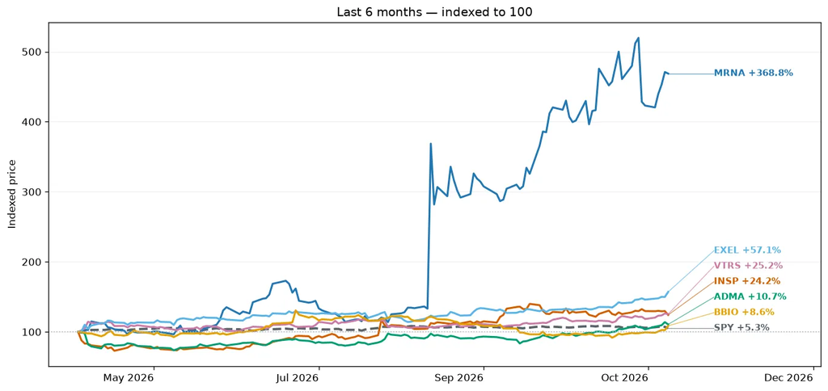

### Last 12 months

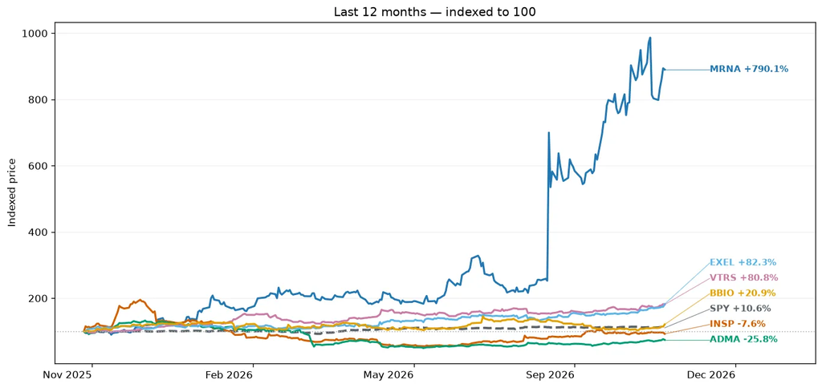

### Last 24 months

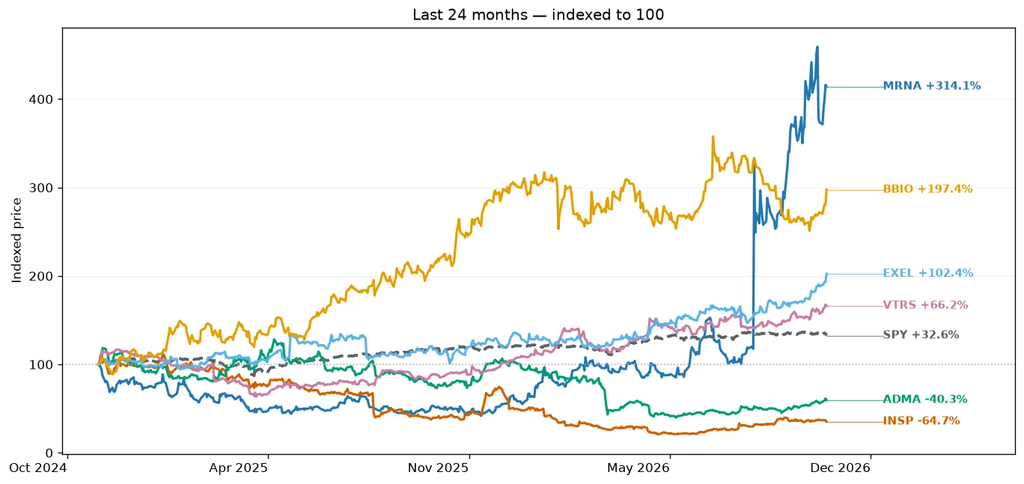

## Current Top Stocks

### Last 3 months

| Rank | Company | Ticker | Market cap | 3m Return |
| --- | --- | --- | --- | --- |
| 1 | Moderna | [MRNA](https://www.google.com/finance/quote/MRNA:NASDAQ?hl=en) | $22.8B | +304.5% |
| 2 | Inspire Medical Systems | [INSP](https://www.google.com/finance/quote/INSP:NYSE?hl=en) | $1.9B | +35.6% |
| 3 | ADMA Biologics | [ADMA](https://www.google.com/finance/quote/ADMA:NASDAQ?hl=en) | $2.1B | +34.9% |
| 4 | Recursion Pharmaceuticals | [RXRX](https://www.google.com/finance/quote/RXRX:NASDAQ?hl=en) | $1.8B | +34.3% |
| 5 | Gilead | [GILD](https://www.google.com/finance/quote/GILD:NASDAQ?hl=en) | $167.9B | +31.1% |

### Last 12 months

| Rank | Company | Ticker | Market cap | 12m Return |
| --- | --- | --- | --- | --- |
| 1 | Moderna | [MRNA](https://www.google.com/finance/quote/MRNA:NASDAQ?hl=en) | $22.8B | +716.3% |
| 2 | Viatris | [VTRS](https://www.google.com/finance/quote/VTRS:NASDAQ?hl=en) | $20.6B | +83.7% |
| 3 | Exelixis | [EXEL](https://www.google.com/finance/quote/EXEL:NASDAQ?hl=en) | $14.1B | +79.4% |
| 4 | Merck | [MRK](https://www.google.com/finance/quote/MRK:NYSE?hl=en) | $316.1B | +73.9% |
| 5 | Krystal Biotech | [KRYS](https://www.google.com/finance/quote/KRYS:NASDAQ?hl=en) | $9.6B | +68.2% |

### Last 24 months

| Rank | Company | Ticker | Market cap | 24m Return |
| --- | --- | --- | --- | --- |
| 1 | Moderna | [MRNA](https://www.google.com/finance/quote/MRNA:NASDAQ?hl=en) | $22.8B | +305.9% |
| 2 | BridgeBio Pharma | [BBIO](https://www.google.com/finance/quote/BBIO:NASDAQ?hl=en) | $16.1B | +194.2% |
| 3 | Exelixis | [EXEL](https://www.google.com/finance/quote/EXEL:NASDAQ?hl=en) | $14.1B | +103.4% |
| 4 | Gilead | [GILD](https://www.google.com/finance/quote/GILD:NASDAQ?hl=en) | $167.9B | +90.7% |
| 5 | Krystal Biotech | [KRYS](https://www.google.com/finance/quote/KRYS:NASDAQ?hl=en) | $9.6B | +88.4% |

## Companies by Subcategory

### Devices & DiagnosticLast 3m: +4.7%

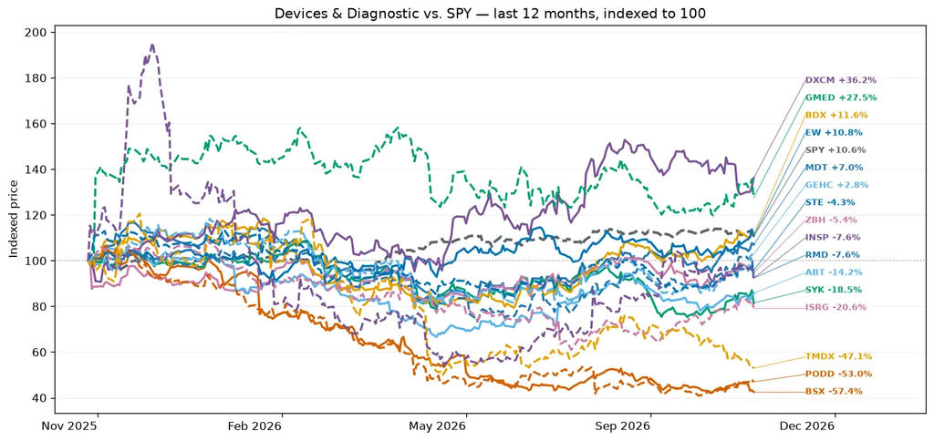

| Company | Ticker | Market cap | 3m Return | 12m Return | 24m Return |
| --- | --- | --- | --- | --- | --- |
| Medtronic | [MDT](https://www.google.com/finance/quote/MDT:NYSE?hl=en) | $110.3B | +13.1% | +6.4% | +7.2% |
| Boston Scientific | [BSX](https://www.google.com/finance/quote/BSX:NYSE?hl=en) | $71.1B | -10.2% | -58.3% | -49.8% |
| Stryker | [SYK](https://www.google.com/finance/quote/SYK:NYSE?hl=en) | $128.9B | -10.4% | -18.1% | -20.5% |
| Zimmer Biomet | [ZBH](https://www.google.com/finance/quote/ZBH:NYSE?hl=en) | $18.5B | +0.6% | -6.0% | -11.9% |
| Abbott | [ABT](https://www.google.com/finance/quote/ABT:NYSE?hl=en) | $182.5B | +0.5% | -14.1% | -10.5% |
| Becton Dickinson | [BDX](https://www.google.com/finance/quote/BDX:NYSE?hl=en) | $48.2B | +19.5% | +10.7% | -15.9% |
| Edwards LifeSciences | [EW](https://www.google.com/finance/quote/EW:NYSE?hl=en) | $51.6B | +6.9% | +11.6% | +36.2% |
| Dexcom | [DXCM](https://www.google.com/finance/quote/DXCM:NASDAQ?hl=en) | $32.8B | -1.4% | +41.3% | +17.0% |
| ResMed | [RMD](https://www.google.com/finance/quote/RMD:NYSE?hl=en) | $32.4B | +9.0% | -6.9% | -5.9% |
| Insulet | [PODD](https://www.google.com/finance/quote/PODD:NASDAQ?hl=en) | $11.6B | -9.5% | -52.2% | -36.5% |
| Globus Medical | [GMED](https://www.google.com/finance/quote/GMED:NYSE?hl=en) | $11.1B | -0.9% | +29.2% | +4.2% |
| Intuitive Surgical | [ISRG](https://www.google.com/finance/quote/ISRG:NASDAQ?hl=en) | $130.1B | +22.3% | -19.1% | -14.7% |
| GE Healthcare | [GEHC](https://www.google.com/finance/quote/GEHC:NASDAQ?hl=en) | $31.7B | +12.6% | +2.2% | -11.9% |
| Transmedics | [TMDX](https://www.google.com/finance/quote/TMDX:NASDAQ?hl=en) | $2.8B | -13.7% | -49.8% | -19.9% |
| STERIS | [STE](https://www.google.com/finance/quote/STE:NYSE?hl=en) | $22.7B | -0.6% | -3.6% | +0.9% |
| Inspire Medical Systems | [INSP](https://www.google.com/finance/quote/INSP:NYSE?hl=en) | $1.9B | +35.6% | -5.5% | -64.3% |

### Big PharmaLast 3m: +12.2%

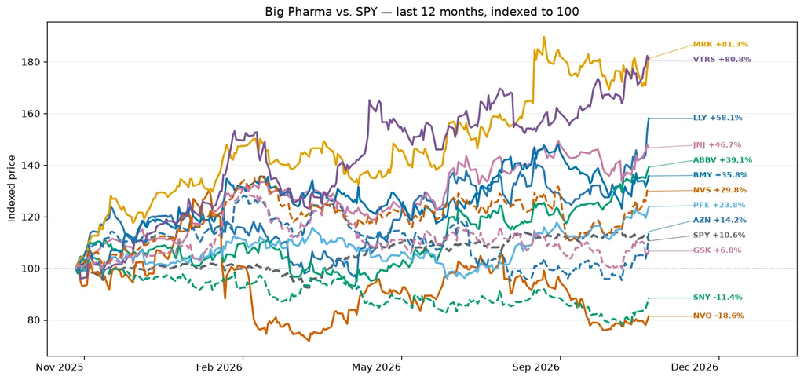

| Company | Ticker | Market cap | 3m Return | 12m Return | 24m Return |
| --- | --- | --- | --- | --- | --- |
| Eli Lilly | [LLY](https://www.google.com/finance/quote/LLY:NYSE?hl=en) | $1.1T | +23.4% | +64.3% | +73.1% |
| Novo Nordisk | [NVO](https://www.google.com/finance/quote/NVO:NYSE?hl=en) | $195.8B | -15.0% | -19.1% | -64.3% |
| AbbVie | [ABBV](https://www.google.com/finance/quote/ABBV:NYSE?hl=en) | $430.8B | +17.5% | +35.2% | +44.9% |
| Johnson & Johnson | [JNJ](https://www.google.com/finance/quote/JNJ:NYSE?hl=en) | $614.4B | +6.6% | +44.6% | +70.6% |
| Pfizer | [PFE](https://www.google.com/finance/quote/PFE:NYSE?hl=en) | $144.8B | +22.0% | +23.8% | +8.7% |
| Merck | [MRK](https://www.google.com/finance/quote/MRK:NYSE?hl=en) | $316.1B | +14.8% | +73.9% | +46.8% |
| Bristol Myers Squibb | [BMY](https://www.google.com/finance/quote/BMY:NYSE?hl=en) | $134.6B | -4.3% | +35.6% | +15.0% |
| Viatris | [VTRS](https://www.google.com/finance/quote/VTRS:NASDAQ?hl=en) | $20.6B | +8.4% | +83.7% | +63.8% |
| AstraZeneca | [AZN](https://www.google.com/finance/quote/AZN:NYSE?hl=en) | $241.3B | +10.0% | +13.3% | +30.7% |
| Novartis | [NVS](https://www.google.com/finance/quote/NVS:NYSE?hl=en) | $291.3B | +3.0% | +29.9% | +47.0% |
| Sanofi | [SNY](https://www.google.com/finance/quote/SNY:NASDAQ?hl=en) | $103.6B | +2.9% | -12.3% | -16.8% |
| GSK | [GSK](https://www.google.com/finance/quote/GSK:NYSE?hl=en) | $103.2B | -4.2% | +5.7% | +34.2% |

### Established BiotechLast 3m: +26.1%

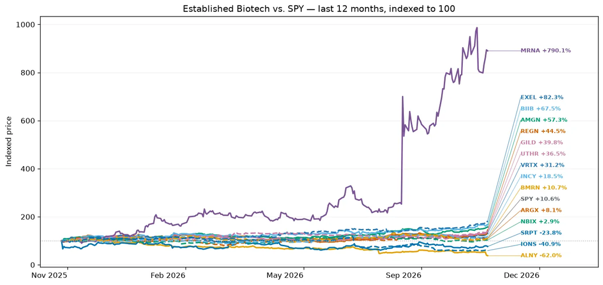

| Company | Ticker | Market cap | 3m Return | 12m Return | 24m Return |
| --- | --- | --- | --- | --- | --- |
| Vertex | [VRTX](https://www.google.com/finance/quote/VRTX:NASDAQ?hl=en) | $121.3B | +17.1% | +31.3% | +18.6% |
| Regeneron | [REGN](https://www.google.com/finance/quote/REGN:NASDAQ?hl=en) | $78.3B | +21.7% | +42.4% | +10.0% |
| Amgen | [AMGN](https://www.google.com/finance/quote/AMGN:NASDAQ?hl=en) | $210.5B | +21.0% | +56.2% | +46.0% |
| Gilead | [GILD](https://www.google.com/finance/quote/GILD:NASDAQ?hl=en) | $167.9B | +31.1% | +42.5% | +90.7% |
| Biogen | [BIIB](https://www.google.com/finance/quote/BIIB:NASDAQ?hl=en) | $30.8B | +25.0% | +64.4% | +45.9% |
| Alnylam | [ALNY](https://www.google.com/finance/quote/ALNY:NASDAQ?hl=en) | $29.3B | -19.7% | -63.8% | -39.8% |
| Sarepta | [SRPT](https://www.google.com/finance/quote/SRPT:NASDAQ?hl=en) | $1.7B | +25.3% | -22.4% | -84.9% |
| Moderna | [MRNA](https://www.google.com/finance/quote/MRNA:NASDAQ?hl=en) | $22.8B | +304.5% | +716.3% | +305.9% |
| Exelixis | [EXEL](https://www.google.com/finance/quote/EXEL:NASDAQ?hl=en) | $14.1B | +30.9% | +79.4% | +103.4% |
| Argenx | [ARGX](https://www.google.com/finance/quote/ARGX:NASDAQ?hl=en) | $52.8B | +4.6% | +9.1% | +49.9% |
| Neurocrine Biosciences | [NBIX](https://www.google.com/finance/quote/NBIX:NASDAQ?hl=en) | $16.9B | -12.4% | +2.0% | +19.5% |
| United Therapeutics | [UTHR](https://www.google.com/finance/quote/UTHR:NASDAQ?hl=en) | $22.0B | +15.6% | +34.4% | +60.1% |
| Incyte | [INCY](https://www.google.com/finance/quote/INCY:NASDAQ?hl=en) | $24.4B | +0.7% | +28.8% | +58.1% |
| BioMarin Pharmaceutical | [BMRN](https://www.google.com/finance/quote/BMRN:NASDAQ?hl=en) | $11.7B | -2.5% | +9.2% | -12.1% |
| Ionis Pharmaceuticals | [IONS](https://www.google.com/finance/quote/IONS:NASDAQ?hl=en) | $9.2B | -15.9% | -41.4% | +12.3% |

### Emerging BiotechLast 3m: -9.7%

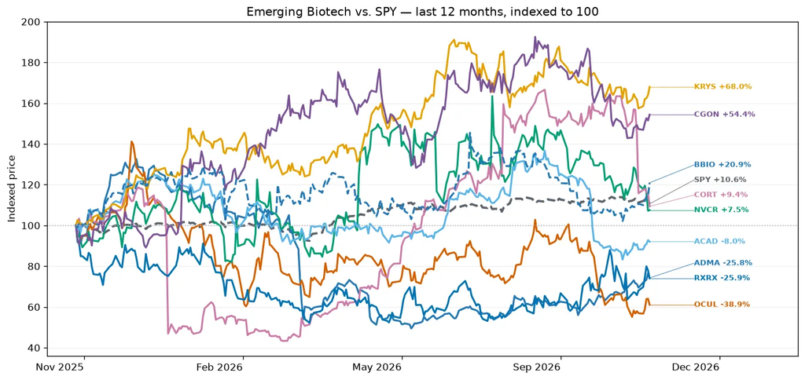

| Company | Ticker | Market cap | 3m Return | 12m Return | 24m Return |
| --- | --- | --- | --- | --- | --- |
| ADMA Biologics | [ADMA](https://www.google.com/finance/quote/ADMA:NASDAQ?hl=en) | $2.1B | +34.9% | -26.3% | -41.1% |
| Ocular therapeutix | [OCUL](https://www.google.com/finance/quote/OCUL:NASDAQ?hl=en) | $1.9B | -14.7% | -40.2% | -32.9% |
| Novocure | [NVCR](https://www.google.com/finance/quote/NVCR:NASDAQ?hl=en) | $1.9B | -11.4% | +2.7% | -18.7% |
| Corcept Therapeutics | [CORT](https://www.google.com/finance/quote/CORT:NASDAQ?hl=en) | $11.9B | -29.1% | +10.4% | +70.3% |
| Acadia Pharmaceuticals | [ACAD](https://www.google.com/finance/quote/ACAD:NASDAQ?hl=en) | $4.6B | -20.4% | -9.3% | +39.0% |
| Krystal Biotech | [KRYS](https://www.google.com/finance/quote/KRYS:NASDAQ?hl=en) | $9.6B | -2.6% | +68.2% | +88.4% |
| Recursion Pharmaceuticals | [RXRX](https://www.google.com/finance/quote/RXRX:NASDAQ?hl=en) | $1.8B | +34.3% | -27.0% | -37.0% |
| CG Oncology | [CGON](https://www.google.com/finance/quote/CGON:NASDAQ?hl=en) | $6.3B | -9.1% | +49.5% | +80.1% |
| BridgeBio Pharma | [BBIO](https://www.google.com/finance/quote/BBIO:NASDAQ?hl=en) | $16.1B | -6.4% | +19.7% | +194.2% |